# Cross-Cohort Cell-Cell Communication in Breast Cancer

- Show All Code
- Hide All Code
- View Source

Conserved ligand-receptor interactions in primary breast tumors

Published

October 21, 2026

Abstract

We integrate three public single-cell RNA-sequencing cohorts of primary breast cancer (74 tumors) and use two ligand-receptor inference frameworks to define a set of 209 interactions that are conserved across cohorts and methods. Five receptor-specific axes were followed up with downstream expression programs, bulk tumor cohorts (TCGA-BRCA, METABRIC, SCAN-B) and spatial transcriptomics. In a primary pooled analysis of overall survival, high FN1-ITGA5/ITGB1 co-expression was associated with worse outcome (HR 1.23, BH q = 0.013), with a similar estimate in SCAN-B. As a continuous score, CCL5-ACKR1 co-expression was associated with better survival (HR 0.88 per SD in the three bulk cohorts), whereas its dichotomized association was null, and T cells co-localized with ACKR1-positive venular endothelium in all six Visium sections. The evidence is observational and supports prioritizing these axes for experimental follow-up. Every step of the analysis is included.

# Overview

Cells in a tumor communicate through ligands that bind receptors on their neighbors. Single-cell RNA sequencing lets us infer which ligand-receptor (L-R) pairs are likely active between cell types, but the inferred interactions depend on the method and on the cohort, and many of them do not appear again in an independent dataset. We ask which L-R interactions in primary breast cancer are conserved across independent cohorts and across inference methods, and whether the conserved ones relate to tumor biology and to patient outcome.

We start from single-cell profiles of 74 primary breast tumors in three public cohorts: Pal et al. (GEO GSE161529, 34 tumors), Wu et al. (GEO GSE176078, 26 tumors) and Qian et al. (Blueprint server, 14 tumors). Each cohort is processed on its own: quality control, doublet removal, batch correction within the cohort, and a leverage-score subsample of 20,000 cells. Cell types come from the published annotations, mapped to one eight-class taxonomy. We then infer communication with two frameworks, CellChat and LIANA, in every cohort separately. An interaction is called conserved when both frameworks detect it in at least two of the three cohorts, which gives a consensus set of 209 interactions. A composite score that combines conservation, agreement between the two methods and a druggability annotation ranks the set. After a general rule that removes promiscuous single-chain matrix receptors, five receptor-specific axes remain at the top: CCL5-ACKR1, APP-CD74, CXCL12-CXCR4, MDK-LRP1 and FN1-ITGA5/ITGB1.

The remaining sections ask what each of the five axes is associated with. Per-sample pseudobulk differential expression and decoupleR describe the transcriptional programs of the receiving cells. A comparison of tumors with normal breast tissue shows whether the axes are tumor-associated. Visium sections from Wu et al. and the independent HER2ST cohort test whether senders and receivers sit next to each other in tissue. In three bulk cohorts, TCGA-BRCA, METABRIC and SCAN-B, we relate axis co-expression to overall survival and to tumor composition. Throughout, we separate primary analyses from secondary and exploratory ones.

Two findings stand out.

1. **FN1-ITGA5/ITGB1 (fibroblast to endothelial cell)** is associated with worse overall survival. In the primary pooled analysis of TCGA-BRCA and METABRIC (2,425 patients), double-high tumors have a hazard ratio of 1.23 (95% CI 1.08-1.41, BH q = 0.013), and SCAN-B gives a similar estimate (HR 1.34, 1.06-1.69, BH q = 0.065). In a model with both genes, FN1 carries most of the bulk signal, so the axis marks a fibronectin-rich stromal and vascular state and does not show that the ligand-receptor pairing is prognostic. In single cells, FN1-high endothelium shows a basement-membrane and angiogenic remodeling program, and in tissue sections fibroblasts and endothelial cells are neighbors, as expected for stroma.
2. **CCL5-ACKR1 (T cell to endothelial cell)** is associated with better survival when co-expression is scored as a continuous variable (HR 0.88 per SD, 95% CI 0.83-0.94, in the three bulk cohorts together). ACKR1 does not signal, so we treat the axis as a reference for T-cell entry through venules and not as a signaling pathway. T cells co-localize with ACKR1-positive venular endothelium in all six Visium sections, and the independent HER2ST cohort points in the same direction without reaching the significance criterion of the primary analysis.

# Reproducing this analysis

## Data sources

All input data are public. The table lists each source, what it is used for and where it sits under `data/`. The directories `data/` and `objects/` are not part of the repository, because of their size, and they are recreated as described below.

| Resource | Accession or link | Used for | Location under `data/` |
| --- | --- | --- | --- |
| Pal et al. 2021, scRNA-seq | GEO GSE161529 (`GSE161529_RAW.tar`) | Discovery cohort; normal breast samples for the tumor-normal comparison | `raw/BCS010/`, `raw/BCS010_normal/`, `GSE161529_RAW.tar` |
| Pal et al. cell annotations | Figshare 17058077 | Barcode-to-cell-type tables built from the published Seurat objects | `meta/er_cell_mapping.csv`, `meta/her2_cell_mapping.csv`, `meta/tnbc_cell_mapping.csv` |
| Wu et al. 2021, scRNA-seq | GEO GSE176078 (`GSE176078_RAW.tar`, cell metadata table) | Discovery cohort and RCTD reference | `raw/BCS014/<sample>/` |
| Qian et al. 2020, scRNA-seq | [Blueprint server](http://blueprint.lambrechtslab.org) (`2102-Breastcancer_counts.tar.gz`, `2103-Breastcancer_metadata.csv.gz`), not deposited in GEO | Discovery cohort | `raw/BCS011/export/BC_counts/`, `meta/2103-Breastcancer_metadata.csv.gz` |
| TCGA-BRCA | cBioPortal study `brca_tcga_pan_can_atlas_2018` (PanCancer Atlas; [archive](https://datahub.assets.cbioportal.org/brca_tcga_pan_can_atlas_2018.tar.gz)) | Bulk expression, clinical data, adjacent-normal profiles | `ext/brca_tcga/` (normals in `ext/brca_tcga/normals/`) |
| TCGA-CDR | Liu et al. 2018, Cell 173:400-416, Table S1 ([GDC page](https://gdc.cancer.gov/about-data/publications/PanCan-Clinical-2018)) | Curated survival endpoints for TCGA | `ext/tcga_cdr/TCGA-CDR-SupplementalTableS1.xlsx` |
| METABRIC | cBioPortal study `brca_metabric` ([archive](https://datahub.assets.cbioportal.org/brca_metabric.tar.gz)) | Bulk expression and clinical data | `ext/brca_metabric/` |
| SCAN-B | GEO GSE96058 (expression matrix and the two series matrices) | Independent validation cohort | `ext/scanb/` |
| Wu et al. 2021, Visium | Zenodo 4739739 | Spatial co-localization in six sections | `spatial/wu2021_visium/` |
| HER2ST, Andersson et al. 2021 | Zenodo 4751624 | Independent spatial cohort, eight patients | `spatial/her2st/` |
| NicheNet v2 prior networks | Zenodo 7074291 (`ligand_target_matrix_nsga2r_final.rds`, `lr_network_human_21122021.rds`, `weighted_networks_nsga2r_final.rds`) | Ligand-target potentials and ligand activity | `nichenet/` |
| CollecTRI | `decoupleR::get_collectri(organism = "human", split_complexes = FALSE)` | Transcription factor regulons | `decoupler/collectri.csv` |
| Therapeutic Target Database | [TTD](https://ttd.idrblab.cn/), file `P2-01-TTD_uniprot_all.txt`, version 10.1.01 (2024-01-10) | Druggability term of the composite score | `ext/P2-01-TTD_uniprot_all.txt` |
| DGIdb | [DGIdb](https://dgidb.org/) v5.0.12, GraphQL API, queried 2026-10-01 | Drug-gene table | response saved in `results/revision/dgidb_raw_response.json` |
| CellChatDB.human | Bundled with CellChat 1.6.1 | Ligand-receptor database for CellChat, adhesion-receptor rule | R package |
| CIBERSORT and LM22 | `CIBERSORT.R` and `LM22.txt` from the [CIBERSORT site](https://cibersortx.stanford.edu/) (registration required) | Immune deconvolution | `ext/CIBERSORT.R`, `ext/LM22.txt` |

## Directory layout

The analysis expects to be run from the repository root, with this layout:

```
analysis.qmd
styles.css
data/                    inputs listed above (not in the repository)
  raw/BCS010/            GSM*-matrix.mtx.gz, GSM*-barcodes.tsv.gz, GSE161529_features.tsv.gz
  raw/BCS010_normal/     the 13 normal "Total" samples, extracted by rev-normals-run
  raw/BCS011/export/BC_counts/   matrix.mtx, barcodes.tsv, genes.tsv
  raw/BCS014/<sample>/   count_matrix_{sparse.mtx,barcodes.tsv,genes.tsv}, metadata.csv
  meta/, ext/, nichenet/, decoupler/, spatial/
objects/                 .qs2 intermediate objects written by the analysis (not in the repository)
results/                 tables and figures written by the analysis
figures/                 figures written by the analysis
```

Each per-sample archive of GSE176078 contains the count matrix and a `metadata.csv` with the cell annotations of Wu et al. (columns `orig.ident`, `nCount_RNA`, `nFeature_RNA`, `percent.mito`, `subtype`, `celltype_major`, `celltype_minor`). The Visium and HER2ST folders are filled by the download steps in the section “Data”.

## Downloading the data

The code below downloads and unpacks every input that has a stable public address. Three inputs need a manual step: the Qian et al. files from the Blueprint server, the TCGA-CDR table (Table S1 of Liu et al. 2018, linked in the table above), and CIBERSORT, which requires registration.

```r
options(timeout = 36000)
geo <- "https://ftp.ncbi.nlm.nih.gov/geo/series"
download_if_missing <- function(url, dest) {
  dir.create(dirname(dest), showWarnings = FALSE, recursive = TRUE)
  if (!file.exists(dest)) download.file(url, dest, mode = "wb")
}

# Pal et al.: one raw archive for all samples, the feature table and the series matrix
download_if_missing(file.path(geo, "GSE161nnn/GSE161529/suppl/GSE161529_RAW.tar"), "data/GSE161529_RAW.tar")
download_if_missing(file.path(geo, "GSE161nnn/GSE161529/suppl/GSE161529_features.tsv.gz"), "data/raw/BCS010/GSE161529_features.tsv.gz")
download_if_missing(file.path(geo, "GSE161nnn/GSE161529/matrix/GSE161529_series_matrix.txt.gz"), "data/meta/GSE161529_series_matrix.txt.gz")
untar("data/GSE161529_RAW.tar", exdir = "data/raw/BCS010")

# Wu et al.: one archive per sample, with the count matrix and the cell metadata
download_if_missing(file.path(geo, "GSE176nnn/GSE176078/suppl/GSE176078_RAW.tar"), "data/GSE176078_RAW.tar")
untar("data/GSE176078_RAW.tar", exdir = "data/GSE176078_samples")
for (f in list.files("data/GSE176078_samples", pattern = "tar.gz$", full.names = TRUE)) untar(f, exdir = "data/raw/BCS014")

# Qian et al.: the two files from http://blueprint.lambrechtslab.org must already be in data/
untar("data/2102-Breastcancer_counts.tar.gz", exdir = "data/raw/BCS011")
dir.create("data/meta", showWarnings = FALSE, recursive = TRUE)
file.copy("data/2103-Breastcancer_metadata.csv.gz", "data/meta/2103-Breastcancer_metadata.csv.gz")

# TCGA-BRCA (PanCancer Atlas) and METABRIC from the cBioPortal datahub
download_if_missing("https://datahub.assets.cbioportal.org/brca_tcga_pan_can_atlas_2018.tar.gz", "data/ext/brcca_tcga.tar.gz")
download_if_missing("https://datahub.assets.cbioportal.org/brca_metabric.tar.gz", "data/ext/brcca_metabric.tar.gz")
untar("data/ext/brcca_tcga.tar.gz", exdir = "data/ext")
file.rename("data/ext/brca_tcga_pan_can_atlas_2018", "data/ext/brca_tcga")
untar("data/ext/brcca_metabric.tar.gz", exdir = "data/ext")

# SCAN-B
for (f in c("suppl/GSE96058_gene_expression_3273_samples_and_136_replicates_transformed.csv.gz",
            "matrix/GSE96058-GPL11154_series_matrix.txt.gz", "matrix/GSE96058-GPL18573_series_matrix.txt.gz")) {
  download_if_missing(file.path(geo, "GSE96nnn/GSE96058", f), file.path("data/ext/scanb", basename(f)))
}

# Therapeutic Target Database and NicheNet prior networks
download_if_missing("https://ttd.idrblab.cn/files/download/P2-01-TTD_uniprot_all.txt", "data/ext/P2-01-TTD_uniprot_all.txt")
for (f in c("ligand_target_matrix_nsga2r_final.rds", "lr_network_human_21122021.rds", "weighted_networks_nsga2r_final.rds")) {
  download_if_missing(file.path("https://zenodo.org/records/7074291/files", f), file.path("data/nichenet", f))
}
```

The CollecTRI table is written by the decoupleR step the first time it runs. The Pal annotation tables in `data/meta/` are built from the Figshare Seurat objects in the section “Single-cell processing”, and the table of Pal primary tumors in the section “Data”.

# Setup

The setup code loads the packages, defines the plotting theme and the cell-type palette, and sets the random seed.

```r
knitr::opts_chunk$set(
  echo = TRUE,
  warning = FALSE,
  message = FALSE,
  eval = FALSE,
  fig.align = "center"
)

# Lightweight Data Manipulation, Visualization & Reporting (for rendering report)
library(dplyr)
library(readr)
library(tidyr)
library(stringr)
library(purrr)
library(data.table)
library(qs2)

# Visualization & Reporting
library(ggplot2)
library(patchwork)
library(DT)
library(knitr)
library(ggVennDiagram)

select <- dplyr::select

theme_publication <- function() {
  theme_minimal(base_size = 12) +
  theme(
    plot.margin = margin(t = 15, r = 15, b = 15, l = 15),
    plot.title = element_text(size = 14, face = "bold", margin = margin(b = 15), hjust = 0.5),
    plot.subtitle = element_text(size = 11, color = "grey40", margin = margin(b = 10), hjust = 0.5),
    axis.title = element_text(size = 13, face = "bold"),
    axis.text = element_text(size = 11, color = "black"),
    legend.title = element_text(size = 11, face = "bold"),
    legend.text = element_text(size = 10),
    panel.border = element_rect(color = "grey80", fill = NA, linewidth = 0.5),
    strip.text = element_text(face = "bold", size = 11)
  )
}

dir.create("objects", showWarnings = FALSE)
dir.create("results/metadata", recursive = TRUE, showWarnings = FALSE)
dir.create("results/characterization", recursive = TRUE, showWarnings = FALSE)
dir.create("results/cross_cohort_comparison", recursive = TRUE, showWarnings = FALSE)

set.seed(42)

num_cores <- parallel::detectCores() - 1
if (is.na(num_cores) || num_cores < 1) num_cores <- 1

cell_type_colors <- c(
  "Cancer"            = "#E69F00",
  "Fibroblast"        = "#56B4E9",
  "Endothelial"       = "#009E73",
  "Myeloid"           = "#F0E442",
  "T_cell"            = "#0072B2",
  "T cell"            = "#0072B2",
  "B_cell"            = "#D55E00",
  "B cell"            = "#D55E00",
  "PVL"               = "#CC79A7",
  "Normal_epithelial" = "#999999",
  "Normal epithelial" = "#999999"
)

# Format a number for the text with a fixed number of significant digits, and values below 0.001 as powers of ten
sg <- function(x, d = 2) {
  e <- floor(log10(abs(x)))
  if (x != 0 && e < -3) {
    return(sprintf("%s × 10<sup>%d</sup>", formatC(x / 10^e, digits = d, format = "fg", flag = "#"), e))
  }
  formatC(x, digits = d, format = "g", flag = "#")
}

# Print one captioned figure per entry (or per entry x inner entry) as panel tabs.
# `template` is the text of a chunk that uses {{key}}, {{title}}, {{inner}} and {{inner_title}}.
fig_tabs <- function(template, keys, titles = keys, inner = NULL, inner_titles = inner) {
  expand <- function(...) {
    cat(knitr::knit_child(text = knitr::knit_expand(text = template, ..., delim = c("{{", "}}")), quiet = TRUE), sep = "\n")
  }
  cat("\n::: {.panel-tabset}\n\n")
  for (i in seq_along(keys)) {
    cat("\n#### ", titles[i], "\n\n", sep = "")
    if (is.null(inner)) {
      expand(key = keys[i], title = titles[i])
    } else {
      cat("::: {.panel-tabset}\n\n")
      for (j in seq_along(inner)) {
        cat("\n##### ", inner_titles[j], "\n\n", sep = "")
        expand(key = keys[i], title = titles[i], inner = inner[j], inner_title = inner_titles[j])
      }
      cat("\n:::\n\n")
    }
  }
  cat("\n:::\n\n")
}
```

The statistical code relies on `survival`, `metafor` and `mice`.

```r
library(survival)
library(metafor)
library(mice)

dir.create("objects/revision", recursive = TRUE, showWarnings = FALSE)
dir.create("results/revision", recursive = TRUE, showWarnings = FALSE)

axis_labels <- c(
  cxcl12_cxcr4 = "CXCL12-CXCR4",
  ccl5_ackr1 = "CCL5-ACKR1",
  mdk_lrp1 = "MDK-LRP1",
  fn1_itga5_itgb1 = "FN1-ITGA5/ITGB1",
  app_cd74 = "APP-CD74"
)
cohort_colors <- c("TCGA" = "#0072B2", "METABRIC" = "#D55E00", "Pooled" = "black")
```

The single-cell, communication and deconvolution steps use the packages below.

```r
# External APIs & Utilities
library(httr)
library(jsonlite)


# Single-Cell & Cell-Cell Communication
library(Matrix)
library(SingleCellExperiment)
library(Seurat)
library(future)
library(harmony)
library(CellChat)
library(liana)
library(scDblFinder)

# Functional Genomics & Pathway Enrichment
library(decoupleR)

# Clinical & Deconvolution Validation
library(immunedeconv)
library(survival)
```

```r
plan("sequential")
options(future.globals.maxSize = 80 * 1024^3)
```

# Data

## Discovery cohorts

The three discovery cohorts are the Pal et al. atlas of human breast tissue (GEO GSE161529), the Wu et al. single-cell atlas of human breast cancers (GEO GSE176078) and the Qian et al. pan-cancer blueprint of the tumor microenvironment (Blueprint server). From each we keep primary breast tumors only. Normal tissue, pre-neoplastic lesions and lymph-node metastases are excluded. The Pal series has 69 samples, and we retain the primary tumors profiled as unsorted (“Total”) cell populations: ER+, PR+, HER2+ and triple-negative tumors, including BRCA1-associated ones.

The sample table of the Pal primary tumors is parsed from the GEO series matrix, which lists each sample’s `cancer type` and `cell population`.

```r
l <- readLines(gzfile("data/meta/GSE161529_series_matrix.txt.gz"))
geo_field <- function(tag) gsub('"', "", strsplit(l[grep(paste0("^!Sample_", tag), l)][1], "\t")[[1]][-1])
geo_char <- lapply(l[grep("^!Sample_characteristics_ch1", l)], function(x) gsub('"', "", strsplit(x, "\t")[[1]][-1]))
names(geo_char) <- vapply(geo_char, function(x) sub(":.*", "", x[1]), character(1))
geo_char <- lapply(geo_char, function(x) trimws(sub("^[^:]*:", "", x)))
pal_samples <- tibble(gsm_id = geo_field("geo_accession"), title = geo_field("title"),
                      cancer_type = geo_char[["cancer type"]], cell_population = geo_char[["cell population"]])
pal_primary <- pal_samples %>%
  filter(cancer_type %in% c("ER+ tumour", "PR+ tumour", "HER2+ tumour", "Triple negative tumour", "Triple negative BRCA1 tumour"),
         cell_population == "Total")
write_csv(pal_primary, "data/meta/pal_primary_tumor_metadata.csv")
```

```r
pal_meta_raw <- read_csv("data/meta/pal_primary_tumor_metadata.csv", show_col_types = FALSE)

knitr::kable(count(pal_meta_raw, cancer_type), caption = "Pal primary tumors by GEO cancer type")
```

Pal primary tumors by GEO cancer type

| cancer_type | n |
| --- | --- |
| ER+ tumour | 19 |
| HER2+ tumour | 6 |
| PR+ tumour | 1 |
| Triple negative BRCA1 tumour | 4 |
| Triple negative tumour | 4 |

Pal et al. contribute 34 primary tumors, Wu et al. 26 and Qian et al. 14, which makes 74 in total. The next step merges the sample records of the three cohorts into one registry and plots the clinical subtype composition (Figure 1).

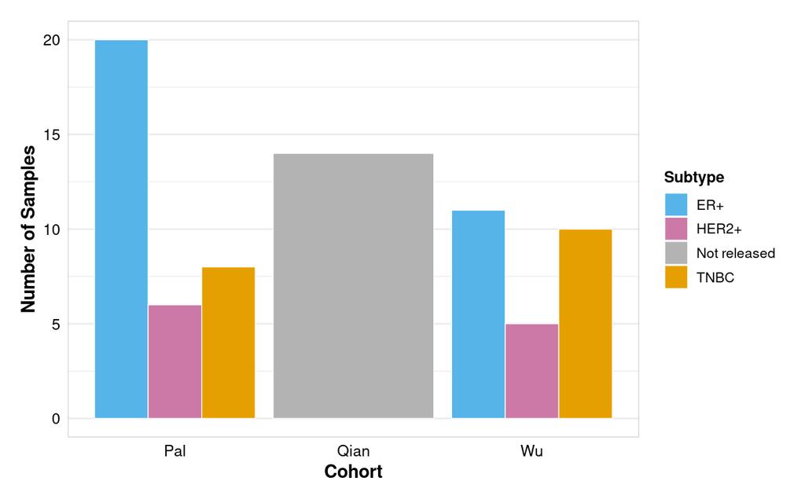

Figure 1: Clinical subtype of the 74 primary tumors in each discovery cohort.

```r
# Pal Metadata
meta_pal_sync <- data.frame(
  sample_id = pal_meta_raw$gsm_id,
  patient_id = paste0("Pal_", gsub(".*-", "", pal_meta_raw$title)),  # Extract patient code
  subtype = case_when(
    pal_meta_raw$cancer_type == "ER+ tumour" ~ "ER+",
    pal_meta_raw$cancer_type == "PR+ tumour" ~ "ER+",  # PR+ is grouped under luminal/ER+
    pal_meta_raw$cancer_type == "HER2+ tumour" ~ "HER2+",
    TRUE ~ "TNBC"
  ),
  cohort = "Pal",
  platform = "10X_3prime",
  tissue_type = "Primary_Tumor",
  stringsAsFactors = FALSE
)

# Wu Metadata: named CID3586 to CID4535. All are primary breast tumors
wu_dirs <- list.dirs("data/raw/BCS014", full.names = FALSE, recursive = FALSE)
# We can load subtype metadata from one of the files
wu_subtypes <- sapply(wu_dirs, function(d) {
  df <- read.csv(file.path("data/raw/BCS014", d, "metadata.csv"), nrows = 1)
  return(df$subtype[1])
})

meta_wu_sync <- data.frame(
  sample_id = wu_dirs,
  patient_id = paste0("Wu_", wu_dirs),
  subtype = case_when(
    wu_subtypes == "ER+" ~ "ER+",
    wu_subtypes == "HER2+" ~ "HER2+",
    TRUE ~ "TNBC"
  ),
  cohort = "Wu",
  platform = "10X_v2_3prime_5prime",
  tissue_type = "Primary_Tumor",
  stringsAsFactors = FALSE
)

# Qian Metadata: a single merged dataset, but contains 14 patients (labeled 41 to 54)
qian_meta_raw <- read_csv("data/meta/2103-Breastcancer_metadata.csv.gz", show_col_types = FALSE)
qian_patients <- unique(qian_meta_raw$PatientNumber)

meta_qian_sync <- data.frame(
  sample_id = paste0("Qian_Patient_", qian_patients),
  patient_id = paste0("Qian_", qian_patients),
  subtype = "Not released", # Qian et al. report mixed subtypes (8 of 14 triple-negative) but release no per-patient subtype
  cohort = "Qian",
  platform = "10X_5prime",
  tissue_type = "Primary_Tumor",
  stringsAsFactors = FALSE
)

# Combine the sample registries of the three cohorts
cohort_metadata <- bind_rows(meta_pal_sync, meta_wu_sync, meta_qian_sync)
write_csv(cohort_metadata, "results/metadata/cohort_metadata.csv")

p_cohort_char <- ggplot(cohort_metadata, aes(x = cohort, fill = subtype)) +
  geom_bar(position = "dodge", color = "white", linewidth = 0.3) +
  scale_fill_manual(values = c("ER+" = "#56B4E9", "HER2+" = "#CC79A7", "TNBC" = "#E69F00", "Not released" = "grey70")) +
  labs(
    x = "Cohort",
    y = "Number of Samples",
    fill = "Subtype"
  ) +
  theme_publication() +
  theme(
    legend.position = "right",
    panel.grid.major.x = element_blank()
  )

dir.create("results/metadata", showWarnings = FALSE, recursive = TRUE)
ggsave("results/metadata/cohort_characteristics.png", plot = p_cohort_char, width = 8, height = 5, dpi = 300)
p_cohort_char
```

| sample_id | patient_id | subtype | cohort | platform | tissue_type |
| --- | --- | --- | --- | --- | --- |
| GSM4909281 | Pal_Triple negative tumour Total cells from Patient 0126 | TNBC | Pal | 10X_3prime | Primary_Tumor |
| GSM4909282 | Pal_Triple negative tumour Total cells from Patient 0135 | TNBC | Pal | 10X_3prime | Primary_Tumor |
| GSM4909283 | Pal_Triple negative tumour Total cells from Patient 0106 | TNBC | Pal | 10X_3prime | Primary_Tumor |
| GSM4909284 | Pal_Triple negative tumour Total cells from Patient 0114 | TNBC | Pal | 10X_3prime | Primary_Tumor |
| GSM4909285 | Pal_Triple negative BRCA1 tumour Total cells from Patient 4031 | TNBC | Pal | 10X_3prime | Primary_Tumor |
| GSM4909286 | Pal_Triple negative BRCA1 tumour Total cells from Patient 0131 | TNBC | Pal | 10X_3prime | Primary_Tumor |
| GSM4909287 | Pal_Triple negative BRCA1 tumour Total cells from Patient 0554 | TNBC | Pal | 10X_3prime | Primary_Tumor |
| GSM4909288 | Pal_Triple negative BRCA1 tumour Total cells from Patient 0177 | TNBC | Pal | 10X_3prime | Primary_Tumor |
| GSM4909289 | Pal_HER2+ tumour Total cells from Patient 0308 | HER2+ | Pal | 10X_3prime | Primary_Tumor |
| GSM4909290 | Pal_HER2+ tumour Total cells from Patient 0337 | HER2+ | Pal | 10X_3prime | Primary_Tumor |

[output cut: 64 more lines]

The cohorts differ in two ways that matter for the analysis. Pal et al. and Wu et al. include all major clinical subtypes, whereas most of the 14 Qian tumors are triple-negative (8 of 14, as reported by Qian et al.), and per-patient subtypes are not released. And the Pal libraries were prepared with 3′ chemistry, the Wu libraries with a mix of 10x v2 3′ and 5′ chemistry and the Qian libraries with 5′ chemistry. We account for both in the analysis. Each cohort is processed and analyzed on its own, with Harmony correcting sample effects only within a cohort, and we then ask which interactions are reproducible across cohorts. We never merge expression values across cohorts. Requiring conservation therefore favors signaling that is shared across subtypes.

## Clinical cohorts

Three bulk cohorts link the communication axes to outcome. TCGA-BRCA (PanCancer Atlas release) contributes 1,082 patients with expression and clinical data, and its survival endpoints are taken from the TCGA Pan-Cancer Clinical Data Resource (TCGA-CDR), together with 114 patient-matched adjacent-normal profiles. METABRIC contributes 1,980 patients with microarray expression. SCAN-B (GEO GSE96058) is an independent population-based cohort with 3,273 tumors profiled by RNA sequencing. TCGA-BRCA and METABRIC were used first. SCAN-B was analyzed afterward, as an independent validation cohort, with its analysis plan written before any SCAN-B survival model was fitted. The processing of the bulk data is described in the section “Clinical associations”.

## Spatial datasets

Two spatial datasets test whether senders and receivers sit next to each other in tissue. The first is the set of six Visium sections from Wu et al. (Zenodo 4739739), four of which come from patients who are also in the Wu single-cell cohort, so they corroborate the discovery data but do not form an independent test. The second is HER2ST (Andersson et al., Zenodo 4751624): 36 spatial transcriptomics sections from eight HER2-positive patients who are not in the discovery cohorts. The Wu single-cell data serve as the reference for deconvolving the spots in both. The two steps below download and unpack the archives, including the H&E images of the primary HER2ST sections. The HER2ST archives are encrypted, and their passwords are published in the data providers’ README at github.com/almaan/her2st.

```r
spatial_dir <- "data/spatial/wu2021_visium"
dir.create(spatial_dir, recursive = TRUE, showWarnings = FALSE)
options(timeout = 36000)

zenodo_files <- c("metadata.tar.gz", "spatial.tar.gz", "filtered_count_matrices.tar.gz", "raw_count_matrices.tar.gz", "images.pdf")
for (f in zenodo_files) {
  dest <- file.path(spatial_dir, f)
  if (!file.exists(dest)) {
    download.file(sprintf("https://zenodo.org/api/records/4739739/files/%s/content", f), dest, mode = "wb")
  }
}
writeLines(paste(tools::md5sum(file.path(spatial_dir, zenodo_files)), zenodo_files), file.path(spatial_dir, "md5sums.txt"))

for (f in grep("tar.gz$", zenodo_files, value = TRUE)) {
  untar(file.path(spatial_dir, f), exdir = spatial_dir)
}
```

```r
her2_dir <- "data/spatial/her2st"
dir.create(her2_dir, recursive = TRUE, showWarnings = FALSE)
options(timeout = 36000)

her2_files <- c("meta.zip", "spot-selections.zip", "count-matrices.zip", "images.zip")
for (f in her2_files) {
  dest <- file.path(her2_dir, f)
  if (!file.exists(dest)) {
    download.file(sprintf("https://zenodo.org/api/records/4751624/files/%s/content", f), dest, mode = "wb")
  }
}
writeLines(paste(tools::md5sum(file.path(her2_dir, her2_files)), her2_files), file.path(her2_dir, "md5sums.txt"))

# Archive passwords are published in the README of the her2st repository (github.com/almaan/her2st)
system2("7z", c("x", "-y", "-pyUx44SzG6NdB32gY", file.path(her2_dir, "meta.zip"), paste0("-o", file.path(her2_dir, "meta"))))
system2("7z", c("x", "-y", "-pyUx44SzG6NdB32gY", file.path(her2_dir, "spot-selections.zip"), paste0("-o", file.path(her2_dir, "spots"))))
system2("7z", c("x", "-y", "-pzNLXkYk3Q9znUseS", file.path(her2_dir, "count-matrices.zip"), paste0("-o", file.path(her2_dir, "counts"))))
# H&E images (same password as the count matrices); only the primary sections are needed
system2("7z", c("x", "-y", "-pzNLXkYk3Q9znUseS", file.path(her2_dir, "images.zip"), paste0("-o", file.path(her2_dir, "images_he")),
                paste0("images/HE/", c("A1", "B1", "C1", "D1", "E1", "F1", "G2", "H1"), ".jpg")))
```

## External resources

Four external resources enter the analysis. NicheNet provides prior ligand-target potentials, and CollecTRI provides transcription factor regulons. The Therapeutic Target Database (TTD, version 10.1.01) provides the druggability term of the composite score, and DGIdb (version 5.0.12) provides the drug-gene table. Accessions and locations are listed in the section “Reproducing this analysis”.

# Single-cell processing

All three cohorts go through the same steps: per-sample quality control with adaptive thresholds, doublet removal, normalization, batch correction within the cohort, and a leverage-score subsample of 20,000 cells for communication inference.

## Quality control and doublet removal

We calculate the median and the median absolute deviation (MAD) of the number of detected genes (`nFeature_RNA`), the number of UMIs (`nCount_RNA`) and the percentage of mitochondrial reads (`percent.mt`) in each sample. A cell is removed if it has more than the median plus three MADs in genes, UMIs or mitochondrial percentage, or fewer genes than the larger of 200 and the median minus three MADs. The mitochondrial cutoff is kept between 5% and 15%, so that unusually clean or unusually stressed samples do not set an extreme threshold. The Qian cohort is delivered as one merged matrix, so its thresholds are set per patient. Doublets are called with `scDblFinder` in each sample and removed. The filtered samples of a cohort are merged.

```r
get_mad_limits <- function(values, nmads = 3) {
  med <- median(values, na.rm = TRUE)
  mad_val <- mad(values, na.rm = TRUE)
  lower <- med - nmads * mad_val
  upper <- med + nmads * mad_val
  return(list(lower = lower, upper = upper))
}
```

```r
if (file.exists("objects/seu_pal_filtered.qs2")) {
  message("Loaded cached Pal filtered object.")
} else {
  read_pal_sample <- function(gsm, raw_dir = "data/raw/BCS010") {
    files <- list.files(raw_dir, full.names = TRUE)
    matrix_file <- files[grep(paste0("^", gsm, ".*matrix.mtx.gz$"), basename(files))]
    barcodes_file <- files[grep(paste0("^", gsm, ".*barcodes.tsv.gz$"), basename(files))]
    features_file <- file.path(raw_dir, "GSE161529_features.tsv.gz")

    mat <- readMM(matrix_file)
    barcodes <- readLines(barcodes_file)
    features <- read.table(features_file, sep = "\t", header = FALSE, stringsAsFactors = FALSE)

    rownames(mat) <- make.unique(features$V2)
    colnames(mat) <- paste0(gsm, "_", barcodes)
    return(mat)
  }

  pal_objects <- list()
  pal_stats <- list()

  for (i in 1:nrow(pal_meta_raw)) {
    gsm <- pal_meta_raw$gsm_id[i]
    title <- pal_meta_raw$title[i]

    counts <- read_pal_sample(gsm)
    seu <- CreateSeuratObject(counts = counts, project = gsm)
    seu$sample_id <- gsm
    seu$patient_id <- paste0("Pal_", gsub(".*-", "", title))
    seu$cohort <- "Pal"

    seu[["percent.mt"]] <- PercentageFeatureSet(seu, pattern = "^MT-")

    feat_lim <- get_mad_limits(seu$nFeature_RNA, nmads = 3)
    count_lim <- get_mad_limits(seu$nCount_RNA, nmads = 3)
    mt_lim <- get_mad_limits(seu$percent.mt, nmads = 3)

    feat_lower <- max(feat_lim$lower, 200)
    feat_upper <- feat_lim$upper
    count_upper <- count_lim$upper
    mt_upper <- min(max(mt_lim$upper, 5), 15)

    n_raw <- ncol(seu)

    seu_qc <- subset(
      seu,
      subset = nFeature_RNA >= feat_lower &
               nFeature_RNA <= feat_upper &
               nCount_RNA <= count_upper &
               percent.mt <= mt_upper
    )

    if (ncol(seu_qc) > 10) {
      sce <- as.SingleCellExperiment(seu_qc)
      sce <- scDblFinder(sce, BPPARAM = BiocParallel::MulticoreParam(workers = 16))
      seu_qc$doublet_class <- sce$scDblFinder.class
      seu_final <- subset(seu_qc, doublet_class == "singlet")
    } else {
      seu_final <- seu_qc
    }

    pal_stats[[gsm]] <- data.frame(
      sample = gsm,
      cells_raw = n_raw,
      cells_qc = ncol(seu_qc),
      cells_final = ncol(seu_final),
      stringsAsFactors = FALSE
    )

    pal_objects[[gsm]] <- seu_final
  }

  pal_stats_df <- bind_rows(pal_stats)
  write_csv(pal_stats_df, "results/characterization/pal_qc_stats.csv")

  seu_pal_merged <- merge(pal_objects[[1]], pal_objects[-1])
  seu_pal_merged <- JoinLayers(seu_pal_merged)
  qs2::qs_save(seu_pal_merged, "objects/seu_pal_filtered.qs2")
}
```

```r
if (file.exists("objects/seu_qian_filtered.qs2")) {
  message("Loaded cached Qian filtered object.")
} else {
  mat_qian <- readMM("data/raw/BCS011/export/BC_counts/matrix.mtx")
  barcodes_qian <- readLines("data/raw/BCS011/export/BC_counts/barcodes.tsv")
  genes_qian <- read.table("data/raw/BCS011/export/BC_counts/genes.tsv", sep = "\t", header = FALSE, stringsAsFactors = FALSE)

  rownames(mat_qian) <- make.unique(genes_qian$V2)
  colnames(mat_qian) <- barcodes_qian

  seu_qian_full <- CreateSeuratObject(counts = mat_qian, project = "Qian")
  seu_qian_full$cohort <- "Qian"

  qian_meta_raw$Cell <- gsub('\"', '', qian_meta_raw$Cell)
  cells_to_keep <- intersect(colnames(seu_qian_full), qian_meta_raw$Cell)
  seu_qian_full <- subset(seu_qian_full, cells = cells_to_keep)

  rownames(qian_meta_raw) <- qian_meta_raw$Cell
  seu_qian_full$patient_id <- paste0("Qian_", qian_meta_raw[colnames(seu_qian_full), ]$PatientNumber)
  seu_qian_full$sample_id <- paste0("Qian_Patient_", qian_meta_raw[colnames(seu_qian_full), ]$PatientNumber)
  seu_qian_full$subtype <- "Not released"

  seu_qian_full[["percent.mt"]] <- PercentageFeatureSet(seu_qian_full, pattern = "^MT-")

  qian_patients_list <- list()
  qian_stats <- list()

  for (pat in unique(seu_qian_full$patient_id)) {
    seu_pat <- subset(seu_qian_full, subset = patient_id == pat)

    feat_lim <- get_mad_limits(seu_pat$nFeature_RNA, nmads = 3)
    count_lim <- get_mad_limits(seu_pat$nCount_RNA, nmads = 3)
    mt_lim <- get_mad_limits(seu_pat$percent.mt, nmads = 3)

    feat_lower <- max(feat_lim$lower, 200)
    feat_upper <- feat_lim$upper
    count_upper <- count_lim$upper
    mt_upper <- min(max(mt_lim$upper, 5), 15)

    n_raw <- ncol(seu_pat)

    seu_qc <- subset(
      seu_pat,
      subset = nFeature_RNA >= feat_lower &
               nFeature_RNA <= feat_upper &
               nCount_RNA <= count_upper &
               percent.mt <= mt_upper
    )

    if (ncol(seu_qc) > 10) {
      sce <- as.SingleCellExperiment(seu_qc)
      sce <- scDblFinder(sce, BPPARAM = BiocParallel::MulticoreParam(workers = 16))
      seu_qc$doublet_class <- sce$scDblFinder.class
      seu_final <- subset(seu_qc, doublet_class == "singlet")
    } else {
      seu_final <- seu_qc
    }

    qian_stats[[pat]] <- data.frame(
      sample = pat,
      cells_raw = n_raw,
      cells_qc = ncol(seu_qc),
      cells_final = ncol(seu_final),
      stringsAsFactors = FALSE
    )

    qian_patients_list[[pat]] <- seu_final
  }

  qian_stats_df <- bind_rows(qian_stats)
  write_csv(qian_stats_df, "results/characterization/qian_qc_stats.csv")

  seu_qian_merged <- merge(qian_patients_list[[1]], qian_patients_list[-1])
  seu_qian_merged <- JoinLayers(seu_qian_merged)
  qs2::qs_save(seu_qian_merged, "objects/seu_qian_filtered.qs2")
}
```

```r
if (file.exists("objects/seu_wu_filtered.qs2")) {
  message("Loaded cached Wu filtered object.")
} else {
  read_wu_sample <- function(sample_dir) {
    matrix_file <- file.path(sample_dir, "count_matrix_sparse.mtx")
    barcodes_file <- file.path(sample_dir, "count_matrix_barcodes.tsv")
    genes_file <- file.path(sample_dir, "count_matrix_genes.tsv")

    mat <- readMM(matrix_file)
    barcodes <- readLines(barcodes_file)
    genes <- readLines(genes_file)

    rownames(mat) <- make.unique(genes)
    colnames(mat) <- paste0(basename(sample_dir), "_", barcodes)
    return(mat)
  }

  wu_objects <- list()
  wu_stats <- list()

  for (i in 1:length(wu_dirs)) {
    sdir <- file.path("data/raw/BCS014", wu_dirs[i])
    sid <- wu_dirs[i]

    counts <- read_wu_sample(sdir)
    seu <- CreateSeuratObject(counts = counts, project = sid)
    seu$sample_id <- sid
    seu$patient_id <- paste0("Wu_", sid)
    seu$cohort <- "Wu"

    seu[["percent.mt"]] <- PercentageFeatureSet(seu, pattern = "^MT-")

    feat_lim <- get_mad_limits(seu$nFeature_RNA, nmads = 3)
    count_lim <- get_mad_limits(seu$nCount_RNA, nmads = 3)
    mt_lim <- get_mad_limits(seu$percent.mt, nmads = 3)

    feat_lower <- max(feat_lim$lower, 200)
    feat_upper <- feat_lim$upper
    count_upper <- count_lim$upper
    mt_upper <- min(max(mt_lim$upper, 5), 15)

    n_raw <- ncol(seu)

    seu_qc <- subset(
      seu,
      subset = nFeature_RNA >= feat_lower &
               nFeature_RNA <= feat_upper &
               nCount_RNA <= count_upper &
               percent.mt <= mt_upper
    )

    if (ncol(seu_qc) > 10) {
      sce <- as.SingleCellExperiment(seu_qc)
      sce <- scDblFinder(sce, BPPARAM = BiocParallel::MulticoreParam(workers = 16))
      seu_qc$doublet_class <- sce$scDblFinder.class
      seu_final <- subset(seu_qc, doublet_class == "singlet")
    } else {
      seu_final <- seu_qc
    }

    wu_stats[[sid]] <- data.frame(
      sample = sid,
      cells_raw = n_raw,
      cells_qc = ncol(seu_qc),
      cells_final = ncol(seu_final),
      stringsAsFactors = FALSE
    )

    wu_objects[[sid]] <- seu_final
  }

  wu_stats_df <- bind_rows(wu_stats)
  write_csv(wu_stats_df, "results/characterization/wu_qc_stats.csv")

  seu_wu_merged <- merge(wu_objects[[1]], wu_objects[-1])
  seu_wu_merged <- JoinLayers(seu_wu_merged)
  qs2::qs_save(seu_wu_merged, "objects/seu_wu_filtered.qs2")
}
```

To show what the filter does, we also need the metrics of the raw cells before filtering. They are computed from the raw matrices.

```r
# Raw per-cell metrics before QC, from the same matrices the filtering chunks read
pal_meta_raw <- read_csv("data/meta/pal_primary_tumor_metadata.csv", show_col_types = FALSE)
features_pal <- read.table("data/raw/BCS010/GSE161529_features.tsv.gz", sep = "\t", header = FALSE, stringsAsFactors = FALSE)
mt_indices_pal <- which(grepl("^MT-", features_pal$V2, ignore.case = TRUE))
pal_before_list <- parallel::mclapply(1:nrow(pal_meta_raw), function(i) {
  gsm <- pal_meta_raw$gsm_id[i]
  files <- list.files("data/raw/BCS010", full.names = TRUE)
  matrix_file <- files[grep(paste0("^", gsm, ".*matrix.mtx.gz$"), basename(files))]
  mat <- Matrix::readMM(matrix_file)
  data.frame(
    nFeature_RNA = colSums(mat > 0),
    nCount_RNA = colSums(mat),
    percent.mt = colSums(mat[mt_indices_pal, , drop = FALSE]) / (colSums(mat) + 1e-5) * 100
  )
}, mc.cores = num_cores)
pal_before <- bind_rows(pal_before_list)

wu_dirs <- list.dirs("data/raw/BCS014", full.names = FALSE, recursive = FALSE)
wu_before_list <- parallel::mclapply(1:length(wu_dirs), function(i) {
  meta <- read_csv(file.path("data/raw/BCS014", wu_dirs[i], "metadata.csv"), show_col_types = FALSE)
  data.frame(nFeature_RNA = meta$nFeature_RNA, nCount_RNA = meta$nCount_RNA, percent.mt = meta$percent.mito)
}, mc.cores = num_cores)
wu_before <- bind_rows(wu_before_list)

qian_meta_raw <- read_csv("data/meta/2103-Breastcancer_metadata.csv.gz", show_col_types = FALSE)
mat_qian <- Matrix::readMM("data/raw/BCS011/export/BC_counts/matrix.mtx")
barcodes_qian <- readLines("data/raw/BCS011/export/BC_counts/barcodes.tsv")
genes_qian <- read.table("data/raw/BCS011/export/BC_counts/genes.tsv", sep = "\t", header = FALSE, stringsAsFactors = FALSE)
mt_indices_qian <- which(grepl("^MT-", genes_qian$V2, ignore.case = TRUE))
colnames(mat_qian) <- barcodes_qian
qian_meta_raw$Cell <- gsub("\"", "", qian_meta_raw$Cell)
cells_to_keep <- intersect(colnames(mat_qian), qian_meta_raw$Cell)
mat_qian_sub <- mat_qian[, cells_to_keep]
qian_before <- data.frame(
  nFeature_RNA = colSums(mat_qian_sub > 0),
  nCount_RNA = colSums(mat_qian_sub),
  percent.mt = colSums(mat_qian_sub[mt_indices_qian, , drop = FALSE]) / (colSums(mat_qian_sub) + 1e-5) * 100
)

qs2::qs_save(list(pal = pal_before, wu = wu_before, qian = qian_before), "objects/qc_before_metrics.qs2")
```

The violin plots compare the three metrics before and after filtering in each cohort (Figure 2, Figure 3, Figure 4).

```r
plot_qc_comparison <- function(df_before, df_after) {
  df_before$status <- "Before filtering"
  df_after$status <- "After filtering"
  df_tidy <- bind_rows(df_before, df_after) %>%
    mutate(status = factor(status, levels = c("Before filtering", "After filtering"))) %>%
    pivot_longer(cols = c(nFeature_RNA, nCount_RNA, percent.mt), names_to = "Metric", values_to = "Value") %>%
    mutate(Metric = factor(case_when(
      Metric == "nFeature_RNA" ~ "Genes per cell",
      Metric == "nCount_RNA" ~ "UMIs per cell",
      Metric == "percent.mt" ~ "Mitochondrial reads (%)"
    ), levels = c("Genes per cell", "UMIs per cell", "Mitochondrial reads (%)")))
  ggplot(df_tidy, aes(x = status, y = Value, fill = status)) +
    geom_violin(scale = "width", adjust = 1, trim = TRUE, alpha = 0.7, color = "grey30") +
    geom_boxplot(width = 0.1, fill = "white", outlier.shape = NA, color = "black") +
    facet_wrap(~Metric, scales = "free_y", ncol = 3) +
    scale_fill_manual(values = c("Before filtering" = "#E69F00", "After filtering" = "#0072B2")) +
    labs(x = NULL, y = "Value") +
    theme_publication() +
    theme(legend.position = "none", panel.spacing = unit(1.5, "lines"))
}

qc_before <- qs2::qs_read("objects/qc_before_metrics.qs2")
qc_after <- lapply(c(pal = "pal", wu = "wu", qian = "qian"), function(coh) {
  m <- qs2::qs_read(sprintf("objects/seu_%s_filtered.qs2", coh))@meta.data
  data.frame(nFeature_RNA = m$nFeature_RNA, nCount_RNA = m$nCount_RNA, percent.mt = m$percent.mt)
})
qc_plots <- lapply(c(pal = "pal", wu = "wu", qian = "qian"), function(coh) plot_qc_comparison(qc_before[[coh]], qc_after[[coh]]))
dir.create("results/qc", showWarnings = FALSE, recursive = TRUE)
for (coh in names(qc_plots)) {
  ggsave(sprintf("results/qc/%s_qc_violin_comparison.png", coh), qc_plots[[coh]], width = 11.5, height = 5.5, dpi = 300)
  ggsave(sprintf("figures/%s_qc_violin_comparison.png", coh), qc_plots[[coh]], width = 11.5, height = 5.5, dpi = 300)
}
```

````r
fig_tabs(
  c("```{r}",
    "#| label: fig-qc-{{key}}",
    "#| eval: true",
    "#| fig-cap: \"Distribution of genes, UMIs and mitochondrial reads per cell before and after quality control in the {{title}}.\"",
    "#| fig-width: 11.5",
    "#| fig-height: 5.5",
    "qc_plots[[\"{{key}}\"]]",
    "```", ""),
  keys = c("pal", "wu", "qian"),
  titles = c("Pal", "Wu", "Qian")
)
````

**Pal**

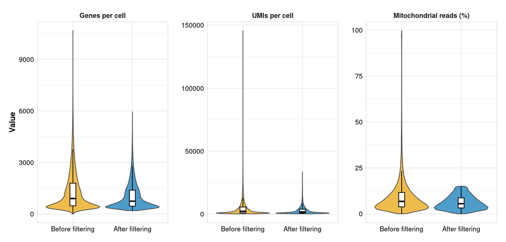

Figure 2: Distribution of genes, UMIs and mitochondrial reads per cell before and after quality control in the Pal.

```r
qc_plots[["pal"]]
```

**Wu**

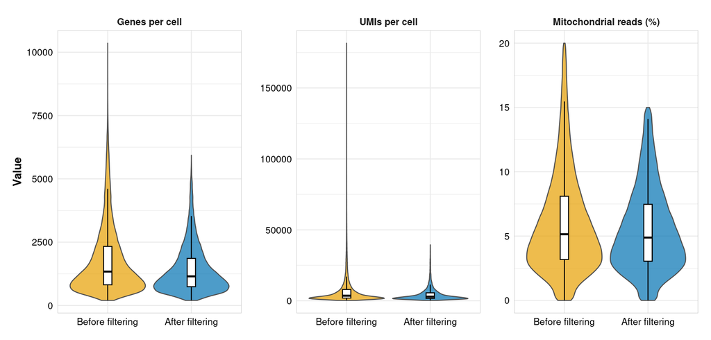

Figure 3: Distribution of genes, UMIs and mitochondrial reads per cell before and after quality control in the Wu.

```r
qc_plots[["wu"]]
```

**Qian**

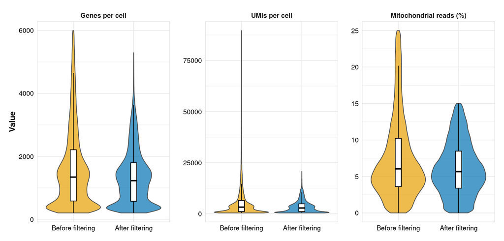

Figure 4: Distribution of genes, UMIs and mitochondrial reads per cell before and after quality control in the Qian.

```r
qc_plots[["qian"]]
```

Cell attrition at each step is summarized per cohort below.

```r
pal_qc <- readr::read_csv("results/characterization/pal_qc_stats.csv", show_col_types = FALSE)
wu_qc <- readr::read_csv("results/characterization/wu_qc_stats.csv", show_col_types = FALSE)
qian_qc <- readr::read_csv("results/characterization/qian_qc_stats.csv", show_col_types = FALSE)
qc_stats_combined <- dplyr::bind_rows(
  pal_qc %>% dplyr::mutate(Cohort = "Pal"),
  wu_qc %>% dplyr::mutate(Cohort = "Wu"),
  qian_qc %>% dplyr::mutate(Cohort = "Qian")
)

qc_summary_cohort <- qc_stats_combined %>%
  dplyr::group_by(Cohort) %>%
  dplyr::summarize(
    Total_Samples = dplyr::n_distinct(sample),
    Raw_Cells = sum(cells_raw),
    Post_QC_Cells = sum(cells_qc),
    Final_Singlets = sum(cells_final),
    .groups = "drop"
  )
knitr::kable(qc_summary_cohort, caption = "Summary of Cellular Attrition Totals Across Cohorts")
```

Summary of Cellular Attrition Totals Across Cohorts

| Cohort | Total_Samples | Raw_Cells | Post_QC_Cells | Final_Singlets |
| --- | --- | --- | --- | --- |
| Pal | 34 | 245073 | 176200 | 160575 |
| Qian | 14 | 44024 | 31711 | 30161 |
| Wu | 26 | 100064 | 82382 | 77680 |

## Integration within each cohort

Patient-specific effects dominate the embedding of unintegrated data and hide the cell types. Within each cohort we therefore normalize, select 2,000 variable genes, run PCA with 30 components, and correct patient effects with Harmony (`max_iter = 10`). Clusters are called on the Harmony embedding at resolution 0.8. We use Harmony rather than the default Seurat integration workflow for its speed on the largest cohort. Integration is applied within a cohort only, for the reasons given in the section “Data”.

```r
if (file.exists("objects/seu_pal_integrated.qs2")) {
  message("Loaded cached Pal integrated object.")
  seu_pal_merged <- qs2::qs_read("objects/seu_pal_integrated.qs2")
} else {
  seu_pal_merged <- qs2::qs_read("objects/seu_pal_filtered.qs2")

  seu_pal_merged <- NormalizeData(seu_pal_merged)
  seu_pal_merged <- FindVariableFeatures(seu_pal_merged, nfeatures = 2000)
  seu_pal_merged <- ScaleData(seu_pal_merged)
  seu_pal_merged <- RunPCA(seu_pal_merged, npcs = 30)

  seu_pal_merged <- RunUMAP(seu_pal_merged, reduction = "pca", dims = 1:30, reduction.name = "umap_before")
  seu_pal_merged <- RunHarmony(seu_pal_merged, group.by.vars = "patient_id", max_iter = 10)
  seu_pal_merged <- RunUMAP(seu_pal_merged, reduction = "harmony", dims = 1:30, reduction.name = "umap_after")
  seu_pal_merged <- FindNeighbors(seu_pal_merged, reduction = "harmony", dims = 1:30)
  seu_pal_merged <- FindClusters(seu_pal_merged, resolution = 0.8)

  qs2::qs_save(seu_pal_merged, "objects/seu_pal_integrated.qs2")
}
```

```r
if (file.exists("objects/seu_qian_integrated.qs2")) {
  message("Loaded cached Qian integrated object.")
  seu_qian_merged <- qs2::qs_read("objects/seu_qian_integrated.qs2")
} else {
  seu_qian_merged <- qs2::qs_read("objects/seu_qian_filtered.qs2")

  seu_qian_merged <- NormalizeData(seu_qian_merged)
  seu_qian_merged <- FindVariableFeatures(seu_qian_merged, nfeatures = 2000)
  seu_qian_merged <- ScaleData(seu_qian_merged)
  seu_qian_merged <- RunPCA(seu_qian_merged, npcs = 30)

  seu_qian_merged <- RunUMAP(seu_qian_merged, reduction = "pca", dims = 1:30, reduction.name = "umap_before")
  seu_qian_merged <- RunHarmony(seu_qian_merged, group.by.vars = "patient_id", max_iter = 10)
  seu_qian_merged <- RunUMAP(seu_qian_merged, reduction = "harmony", dims = 1:30, reduction.name = "umap_after")
  seu_qian_merged <- FindNeighbors(seu_qian_merged, reduction = "harmony", dims = 1:30)
  seu_qian_merged <- FindClusters(seu_qian_merged, resolution = 0.8)

  qs2::qs_save(seu_qian_merged, "objects/seu_qian_integrated.qs2")
}
```

```r
if (file.exists("objects/seu_wu_integrated.qs2")) {
  message("Loaded cached Wu integrated object.")
  seu_wu_merged <- qs2::qs_read("objects/seu_wu_integrated.qs2")
} else {
  seu_wu_merged <- qs2::qs_read("objects/seu_wu_filtered.qs2")

  seu_wu_merged <- NormalizeData(seu_wu_merged)
  seu_wu_merged <- FindVariableFeatures(seu_wu_merged, nfeatures = 2000)
  seu_wu_merged <- ScaleData(seu_wu_merged)
  seu_wu_merged <- RunPCA(seu_wu_merged, npcs = 30)

  seu_wu_merged <- RunUMAP(seu_wu_merged, reduction = "pca", dims = 1:30, reduction.name = "umap_before")
  seu_wu_merged <- RunHarmony(seu_wu_merged, group.by.vars = "patient_id", max_iter = 10)
  seu_wu_merged <- RunUMAP(seu_wu_merged, reduction = "harmony", dims = 1:30, reduction.name = "umap_after")
  seu_wu_merged <- FindNeighbors(seu_wu_merged, reduction = "harmony", dims = 1:30)
  seu_wu_merged <- FindClusters(seu_wu_merged, resolution = 0.8)

  qs2::qs_save(seu_wu_merged, "objects/seu_wu_integrated.qs2")
}
```

The UMAPs below color cells by patient. After Harmony, cells from different patients mix, and the remaining structure reflects cell types, states and subtypes more than technical differences (Figure 5, Figure 6, Figure 7).

```r
integration_plots <- lapply(c(pal = "pal", wu = "wu", qian = "qian"), function(coh) {
  seu <- qs2::qs_read(sprintf("objects/seu_%s_integrated.qs2", coh))
  umap_panel <- function(reduction) {
    Seurat::DimPlot(seu, reduction = reduction, group.by = "patient_id") +
      theme_publication() +
      theme(legend.position = "none") +
      labs(title = NULL, x = "UMAP 1", y = "UMAP 2")
  }
  p_before <- umap_panel("umap_before")
  p_after <- umap_panel("umap_after")
  dir.create("results/integration", showWarnings = FALSE, recursive = TRUE)
  ggsave(sprintf("results/integration/%s_integration_before.png", coh), p_before, width = 6, height = 5.5, dpi = 300)
  ggsave(sprintf("results/integration/%s_integration_after.png", coh), p_after, width = 6, height = 5.5, dpi = 300)
  p_pair <- (p_before + p_after) + plot_annotation(tag_levels = "A")
  ggsave(sprintf("results/integration/%s_integration_umap.png", coh), p_pair, width = 12, height = 5.5, dpi = 300)
  rm(seu)
  gc()
  p_pair
})
```

````r
fig_tabs(
  c("```{r}",
    "#| label: fig-integration-{{key}}",
    "#| eval: true",
    "#| fig-format: jpeg",
    "#| fig-dpi: 60",
    "#| dev.args: !expr list(quality = 85)",
    "#| fig-cap: \"UMAP of the {{title}} cohort before (A) and after (B) Harmony integration. Each color is one patient.\"",
    "#| fig-width: 12",
    "#| fig-height: 5.5",
    "integration_plots[[\"{{key}}\"]]",
    "```", ""),
  keys = c("pal", "wu", "qian"),
  titles = c("Pal", "Wu", "Qian")
)
````

**Pal**

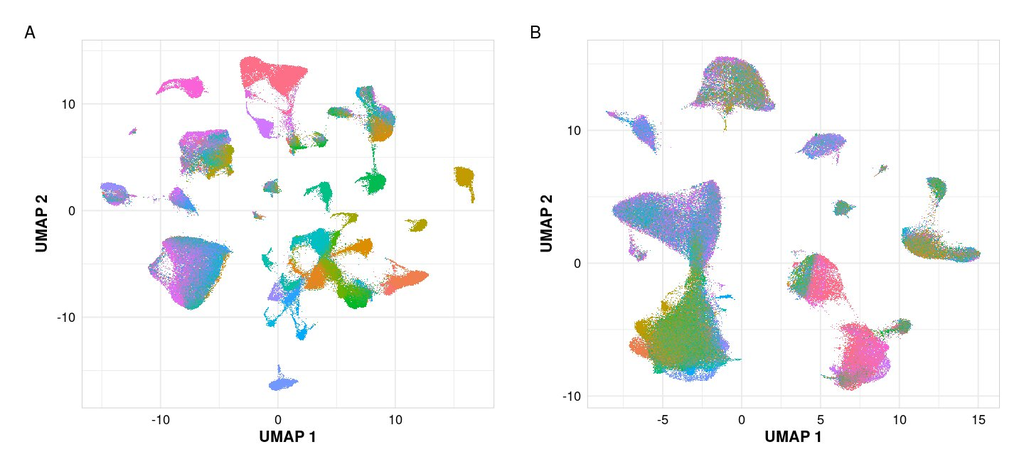

Figure 5: UMAP of the Pal cohort before (A) and after (B) Harmony integration. Each color is one patient.

```r
integration_plots[["pal"]]
```

**Wu**

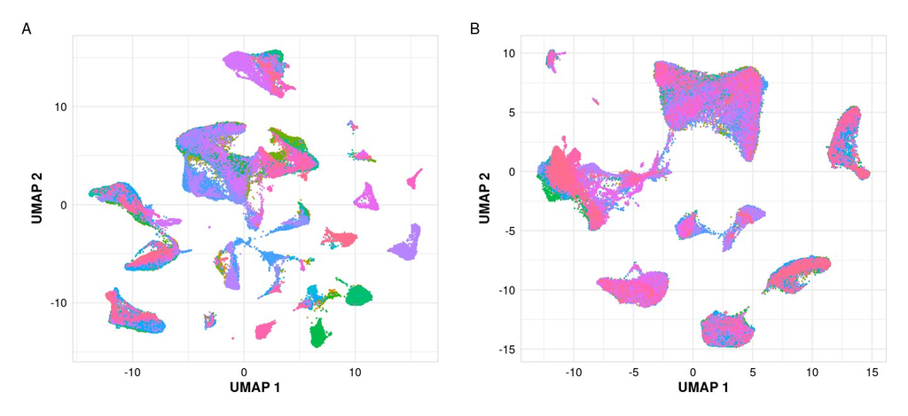

Figure 6: UMAP of the Wu cohort before (A) and after (B) Harmony integration. Each color is one patient.

```r
integration_plots[["wu"]]
```

**Qian**

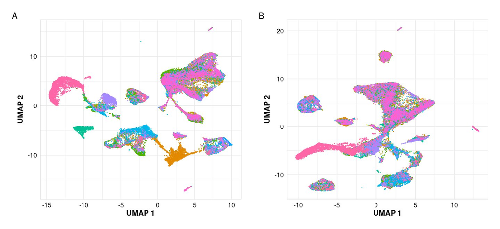

Figure 7: UMAP of the Qian cohort before (A) and after (B) Harmony integration. Each color is one patient.

```r
integration_plots[["qian"]]
```

## Leverage-score sketching

```r
TARGET_SKETCH <- 20000
```

```r
pal_qc <- readr::read_csv("results/characterization/pal_qc_stats.csv", show_col_types = FALSE)
wu_qc <- readr::read_csv("results/characterization/wu_qc_stats.csv", show_col_types = FALSE)
qian_qc <- readr::read_csv("results/characterization/qian_qc_stats.csv", show_col_types = FALSE)
dplyr::bind_rows(
  pal_qc %>% dplyr::mutate(Cohort = "Pal"),
  wu_qc %>% dplyr::mutate(Cohort = "Wu"),
  qian_qc %>% dplyr::mutate(Cohort = "Qian")
) %>%
  dplyr::group_by(Cohort) %>%
  dplyr::summarize(
    Total_Samples = dplyr::n_distinct(sample),
    Final_Singlets = sum(cells_final),
    .groups = "drop"
  ) %>%
  knitr::kable(caption = "Final Singlet Cell Counts Across Cohorts")
```

Final Singlet Cell Counts Across Cohorts

| Cohort | Total_Samples | Final_Singlets |
| --- | --- | --- |
| Pal | 34 | 160575 |
| Qian | 14 | 30161 |
| Wu | 26 | 77680 |

Each cohort contains tens of thousands to hundreds of thousands of cells, which is too many for CellChat and LIANA to run in a reasonable time. We reduce every cohort to at most 20,000 cells with the leverage-score sketching of Seurat v5, which samples cells in proportion to how much each one contributes to the geometry of the data, so that rare cell types are kept. The sketch is then normalized, scaled and embedded again. Metadata and annotations remain attached to the cells. All three cohorts have more cells than the target, so each is subsampled: the sketch keeps 12% of the Pal cells, 26% of the Wu cells and 66% of the Qian cells (cell counts in the table above). The section “Robustness to subsampling” checks how much the results depend on this choice.

```r
if (file.exists(paste0("objects/seu_pal_sketched_", TARGET_SKETCH, ".qs2"))) {
  message("Loaded cached Pal sketched object.")
} else {
  seu_pal_merged <- qs2::qs_read("objects/seu_pal_integrated.qs2")

  n_sketch <- min(ncol(seu_pal_merged), TARGET_SKETCH)
  message(sprintf("Sketching Pal cohort to %d cells.", n_sketch))
  seu_pal_sketched <- SketchData(
    object = seu_pal_merged,
    ncells = n_sketch,
    method = "LeverageScore",
    sketched.assay = "sketch"
  )
  DefaultAssay(seu_pal_sketched) <- "sketch"

  seu_pal_sketched <- NormalizeData(seu_pal_sketched)
  seu_pal_sketched <- FindVariableFeatures(seu_pal_sketched, nfeatures = 2000)
  seu_pal_sketched <- ScaleData(seu_pal_sketched)
  seu_pal_sketched <- RunPCA(seu_pal_sketched, npcs = 30)
  seu_pal_sketched <- RunUMAP(seu_pal_sketched, dims = 1:30)

  qs2::qs_save(seu_pal_sketched, paste0("objects/seu_pal_sketched_", TARGET_SKETCH, ".qs2"))
}
```

```r
if (file.exists(paste0("objects/seu_qian_sketched_", TARGET_SKETCH, ".qs2"))) {
  message("Loaded cached Qian sketched object.")
} else {
  seu_qian_merged <- qs2::qs_read("objects/seu_qian_integrated.qs2")

  n_sketch <- min(ncol(seu_qian_merged), TARGET_SKETCH)
  seu_qian_sketched <- SketchData(
    object = seu_qian_merged,
    ncells = n_sketch,
    method = "LeverageScore",
    sketched.assay = "sketch"
  )
  DefaultAssay(seu_qian_sketched) <- "sketch"

  seu_qian_sketched <- NormalizeData(seu_qian_sketched)
  seu_qian_sketched <- FindVariableFeatures(seu_qian_sketched, nfeatures = 2000)
  seu_qian_sketched <- ScaleData(seu_qian_sketched)
  seu_qian_sketched <- RunPCA(seu_qian_sketched, npcs = 30)
  seu_qian_sketched <- RunUMAP(seu_qian_sketched, dims = 1:30)

  qs2::qs_save(seu_qian_sketched, paste0("objects/seu_qian_sketched_", TARGET_SKETCH, ".qs2"))
}
```

```r
if (file.exists(paste0("objects/seu_wu_sketched_", TARGET_SKETCH, ".qs2"))) {
  message("Loaded cached Wu sketched object.")
} else {
  seu_wu_merged <- qs2::qs_read("objects/seu_wu_integrated.qs2")

  n_sketch <- min(ncol(seu_wu_merged), TARGET_SKETCH)
  message(sprintf("Sketching Wu cohort to %d cells.", n_sketch))
  seu_wu_sketched <- SketchData(
    object = seu_wu_merged,
    ncells = n_sketch,
    method = "LeverageScore",
    sketched.assay = "sketch"
  )
  DefaultAssay(seu_wu_sketched) <- "sketch"

  seu_wu_sketched <- NormalizeData(seu_wu_sketched)
  seu_wu_sketched <- FindVariableFeatures(seu_wu_sketched, nfeatures = 2000)
  seu_wu_sketched <- ScaleData(seu_wu_sketched)
  seu_wu_sketched <- RunPCA(seu_wu_sketched, npcs = 30)
  seu_wu_sketched <- RunUMAP(seu_wu_sketched, dims = 1:30)

  qs2::qs_save(seu_wu_sketched, paste0("objects/seu_wu_sketched_", TARGET_SKETCH, ".qs2"))
}
```

The sketched cells (red in the second panel) are spread over the whole UMAP of the full cohort, and the third panel shows that patients stay mixed in the subsample (Figure 8, Figure 9, Figure 10).

```r
sketch_plots <- lapply(c(pal = "pal", wu = "wu", qian = "qian"), function(coh) {
  seu <- qs2::qs_read(sprintf("objects/seu_%s_sketched_%d.qs2", coh, TARGET_SKETCH))
  sketch_cells <- colnames(seu[["sketch"]])
  p1 <- Seurat::DimPlot(seu, reduction = "umap_after", group.by = "patient_id", raster = TRUE) +
    labs(title = NULL, x = "UMAP 1", y = "UMAP 2") + theme_publication() + theme(legend.position = "none")
  p2 <- Seurat::DimPlot(seu, reduction = "umap_after", cells.highlight = sketch_cells,
                        cols.highlight = "#D55E00", cols = "grey90", raster = TRUE) +
    labs(title = NULL, x = "UMAP 1", y = "UMAP 2") + theme_publication() + theme(legend.position = "none")
  p3 <- Seurat::DimPlot(seu, reduction = "umap_after", cells = sketch_cells, group.by = "patient_id", raster = FALSE) +
    labs(title = NULL, x = "UMAP 1", y = "UMAP 2") + theme_publication() + theme(legend.position = "none")
  p <- (p1 + p2 + p3) + plot_layout(ncol = 3) + plot_annotation(tag_levels = "A")
  ggsave(sprintf("results/characterization/%s_sketch_validation.png", coh), p, width = 15, height = 5.5, dpi = 300)
  rm(seu)
  gc()
  p
})
```

````r
fig_tabs(
  c("```{r}",
    "#| label: fig-sketch-{{key}}",
    "#| eval: true",
    "#| fig-format: jpeg",
    "#| fig-dpi: 60",
    "#| dev.args: !expr list(quality = 85)",
    "#| fig-cap: \"Leverage-score sketch of the {{title}} cohort. A, all cells, colored by patient. B, the 20,000 sketched cells in red. C, the sketched cells only, colored by patient.\"",
    "#| fig-width: 15",
    "#| fig-height: 5.5",
    "sketch_plots[[\"{{key}}\"]]",
    "```", ""),
  keys = c("pal", "wu", "qian"),
  titles = c("Pal", "Wu", "Qian")
)
````

**Pal**

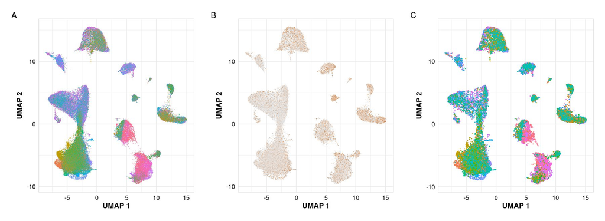

Figure 8: Leverage-score sketch of the Pal cohort. A, all cells, colored by patient. B, the 20,000 sketched cells in red. C, the sketched cells only, colored by patient.

```r
sketch_plots[["pal"]]
```

**Wu**

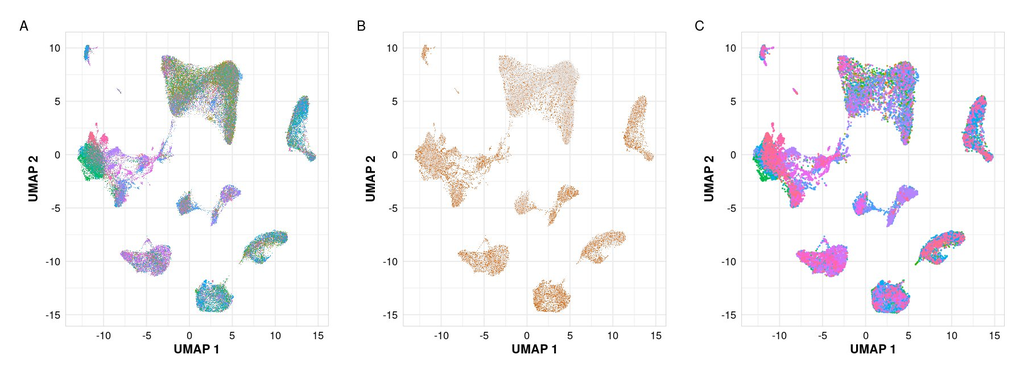

Figure 9: Leverage-score sketch of the Wu cohort. A, all cells, colored by patient. B, the 20,000 sketched cells in red. C, the sketched cells only, colored by patient.

```r
sketch_plots[["wu"]]
```

**Qian**

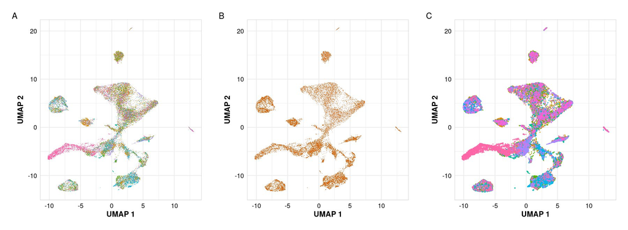

Figure 10: Leverage-score sketch of the Qian cohort. A, all cells, colored by patient. B, the 20,000 sketched cells in red. C, the sketched cells only, colored by patient.

```r
sketch_plots[["qian"]]
```

## Cell-type annotation and harmonization

Annotating cells de novo adds its own variability, because clustering resolution, marker choice and batch effects all differ between datasets. We therefore use the cell types that each study assigned, which were curated with the whole cohort in view, and map them to one eight-class taxonomy. For Pal et al. the labels come from the published Seurat objects on Figshare, matched through the barcode prefix. Cells that are absent from those objects get the majority label of their Harmony cluster. For Wu et al. we use the `celltype_major` column of the published metadata, and for Qian et al. the `CellType` column.

The eight classes are `B_cell`, `T_cell`, `Myeloid`, `Endothelial`, `Fibroblast`, `PVL`, `Normal_epithelial` and `Cancer`. Finer labels are collapsed into the coarser class that all three studies share. NK cells go into `T_cell`, because the Qian annotation does not separate them. Mast cells, which are rare in all cohorts and would form an unstable class, go into `Myeloid` together with dendritic cells. Cancer-associated fibroblasts (CAFs) become `Fibroblast`, and pericytes become `PVL` (perivascular-like cells). No cells are discarded, and the harmonized label is stored in a new metadata column, `harmonized_label`.

| Cohort | Original labels | Harmonized class |
| --- | --- | --- |
| Pal | B_cell, T_cell, NK_cell, Myeloid, Mast_cell, Endothelial, Fibroblast, PVL, Cancer, Normal_epithelial | `B_cell` (B_cell), `T_cell` (T_cell, NK_cell), `Myeloid` (Myeloid, Mast_cell), `Endothelial`, `Fibroblast`, `PVL`, `Cancer`, `Normal_epithelial` |
| Wu | B-cells, Plasmablasts, T-cells, Myeloid, Endothelial, CAFs, PVL, Normal Epithelial, Cancer Epithelial | `B_cell` (B-cells, Plasmablasts), `T_cell` (T-cells), `Myeloid`, `Endothelial`, `Fibroblast` (CAFs), `PVL`, `Normal_epithelial` (Normal Epithelial), `Cancer` (Cancer Epithelial) |
| Qian | B_cell, T_cell, Myeloid, DC, Mast, EC, Fibroblast, Cancer | `B_cell`, `T_cell`, `Myeloid` (Myeloid, DC, Mast), `Endothelial` (EC), `Fibroblast`, `Cancer`; any other label is assigned to `Cancer` |

For the Pal cohort the published labels come from the Figshare Seurat objects. The next step turns their cluster labels into the barcode-to-cell-type tables used below (`data/meta/*_cell_mapping.csv`).

```r
# The published Seurat objects (Figshare 17058077) hold cluster labels but not cell types. We give each
# cluster of the "Sub" objects the cell type with the highest mean marker expression, and label the
# remaining clusters of the main objects with fixed rules (cancer and normal epithelial clusters).
figshare_dir <- "tmp"
dir.create(figshare_dir, showWarnings = FALSE)
figshare_files <- jsonlite::fromJSON("https://api.figshare.com/v2/articles/17058077/files?page_size=100")
needed <- paste0("SeuratObject_", c("HER2", "HER2Sub", "TNBC", "TNBCSub", "ERTotal", "ERTotalSub"), ".rds")
figshare_files <- figshare_files[figshare_files$name %in% needed, ]
for (k in seq_len(nrow(figshare_files))) {
  dest <- file.path(figshare_dir, figshare_files$name[k])
  if (!file.exists(dest)) download.file(figshare_files$download_url[k], dest, mode = "wb")
}

marker_list <- list(
  B_cell = c("CD19", "CD79A", "MS4A1"),
  T_cell = c("CD3E", "CD3D", "CD3G", "CD4", "CD8A", "CD8B"),
  NK_cell = c("GNLY", "NKG7", "NCAM1", "KLRD1"),
  Myeloid = c("CD68", "CD14", "FCGR3A", "CST3", "HLA-DRA", "CD74"),
  Fibroblast = c("PDGFRA", "PDGFRB", "COL1A1", "COL1A2", "COL3A1", "FAP"),
  Endothelial = c("PECAM1", "CD34", "VWF", "PROCR"),
  PVL = c("RGS5", "ACTA2", "MCAM", "DES"),
  Mast_cell = c("TPSAB1", "TPSB2", "CPA3")
)

# Map each cluster to the cell type with the highest mean marker expression
get_cluster_mapping <- function(sub_obj, sub_name) {
  all_marker_genes <- unique(unlist(marker_list))

  assay_name <- "RNA"
  if (!("RNA" %in% names(sub_obj@assays))) {
    assay_name <- names(sub_obj@assays)[1]
  }

  data_mat <- sub_obj@assays[[assay_name]]@data
  all_marker_genes <- intersect(all_marker_genes, rownames(data_mat))

  marker_mat <- data_mat[all_marker_genes, , drop = FALSE]

  clusters <- as.character(sub_obj@meta.data$seurat_clusters)
  unique_clusters <- unique(clusters)

  avg_expr <- matrix(0, nrow = length(all_marker_genes), ncol = length(unique_clusters),
                     dimnames = list(all_marker_genes, unique_clusters))

  for (clst in unique_clusters) {
    cells_in_clst <- which(clusters == clst)
    if (length(cells_in_clst) > 1) {
      avg_expr[, clst] <- Matrix::rowMeans(marker_mat[, cells_in_clst, drop = FALSE])
    } else if (length(cells_in_clst) == 1) {
      avg_expr[, clst] <- as.numeric(marker_mat[, cells_in_clst])
    }
  }

  cluster_mapping <- c()
  for (clst in unique_clusters) {
    scores <- sapply(names(marker_list), function(ct) {
      genes <- intersect(marker_list[[ct]], rownames(avg_expr))
      if (length(genes) == 0) return(0)
      mean(avg_expr[genes, clst, drop = TRUE])
    })
    assigned_ct <- names(scores)[which.max(scores)]
    cluster_mapping <- c(cluster_mapping, setNames(assigned_ct, clst))
  }
  return(cluster_mapping)
}

h2_main <- readRDS(file.path(figshare_dir, "SeuratObject_HER2.rds"))
h2_sub <- readRDS(file.path(figshare_dir, "SeuratObject_HER2Sub.rds"))
h2_sub_map <- get_cluster_mapping(h2_sub, "HER2 Sub")

h2_cells <- data.frame(
  cell_barcode = rownames(h2_main@meta.data),
  group = h2_main@meta.data$group,
  seurat_clusters = h2_main@meta.data$seurat_clusters,
  stringsAsFactors = FALSE
)

h2_sub_meta <- data.frame(
  cell_barcode = rownames(h2_sub@meta.data),
  sub_clusters = h2_sub@meta.data$seurat_clusters,
  stringsAsFactors = FALSE
)

h2_cells <- h2_cells %>%
  left_join(h2_sub_meta, by = "cell_barcode")

h2_cells <- h2_cells %>%
  mutate(
    celltype = case_when(
      !is.na(sub_clusters) ~ h2_sub_map[as.character(sub_clusters)],
      seurat_clusters %in% c(0, 3) ~ "Cancer",
      seurat_clusters == 7 ~ "Normal_epithelial",
      TRUE ~ NA_character_
    )
  )
write_csv(h2_cells, "data/meta/her2_cell_mapping.csv")

tn_main <- readRDS(file.path(figshare_dir, "SeuratObject_TNBC.rds"))
tn_sub <- readRDS(file.path(figshare_dir, "SeuratObject_TNBCSub.rds"))
tn_sub_map <- get_cluster_mapping(tn_sub, "TNBC Sub")

tn_cells <- data.frame(
  cell_barcode = rownames(tn_main@meta.data),
  group = tn_main@meta.data$group,
  seurat_clusters = tn_main@meta.data$seurat_clusters,
  stringsAsFactors = FALSE
)

tn_sub_meta <- data.frame(
  cell_barcode = rownames(tn_sub@meta.data),
  sub_clusters = tn_sub@meta.data$seurat_clusters,
  stringsAsFactors = FALSE
)

tn_cells <- tn_cells %>%
  left_join(tn_sub_meta, by = "cell_barcode")

tn_cells <- tn_cells %>%
  mutate(
    celltype = case_when(
      !is.na(sub_clusters) ~ tn_sub_map[as.character(sub_clusters)],
      seurat_clusters %in% c(0, 2) ~ "Cancer",
      TRUE ~ NA_character_
    )
  )
write_csv(tn_cells, "data/meta/tnbc_cell_mapping.csv")

er_main <- readRDS(file.path(figshare_dir, "SeuratObject_ERTotal.rds"))
er_sub <- readRDS(file.path(figshare_dir, "SeuratObject_ERTotalSub.rds"))
er_sub_map <- get_cluster_mapping(er_sub, "ER Sub")

er_cells <- data.frame(
  cell_barcode = rownames(er_main@meta.data),
  group = er_main@meta.data$group,
  seurat_clusters = er_main@meta.data$seurat_clusters,
  stringsAsFactors = FALSE
)

er_sub_meta <- data.frame(
  cell_barcode = rownames(er_sub@meta.data),
  sub_clusters = er_sub@meta.data$seurat_clusters,
  stringsAsFactors = FALSE
)

er_cells <- er_cells %>%
  left_join(er_sub_meta, by = "cell_barcode")

er_cells <- er_cells %>%
  mutate(
    celltype = case_when(
      !is.na(sub_clusters) ~ er_sub_map[as.character(sub_clusters)],
      seurat_clusters %in% c(0, 4) ~ "Cancer",
      seurat_clusters %in% c(5, 6) ~ "Normal_epithelial",
      TRUE ~ NA_character_
    )
  )
write_csv(er_cells, "data/meta/er_cell_mapping.csv")
```

```r
if (file.exists(paste0("objects/seu_pal_harmonized_", TARGET_SKETCH, ".qs2"))) {
  message("Loaded cached Pal harmonized object.")
} else {
  seu_pal_sketched <- qs2::qs_read(paste0("objects/seu_pal_sketched_", TARGET_SKETCH, ".qs2"))

  h2_map <- read_csv("data/meta/her2_cell_mapping.csv", show_col_types = FALSE)
  tn_map <- read_csv("data/meta/tnbc_cell_mapping.csv", show_col_types = FALSE)
  er_map <- read_csv("data/meta/er_cell_mapping.csv", show_col_types = FALSE)

  map_author_type <- function(x) {
    case_when(
      x == "NK_cell" ~ "T_cell",
      x == "T_cell" ~ "T_cell",
      x == "Myeloid" ~ "Myeloid",
      x == "Fibroblast" ~ "Fibroblast",
      x == "PVL" ~ "PVL",
      x == "Endothelial" ~ "Endothelial",
      x == "Mast_cell" ~ "Myeloid",
      x == "B_cell" ~ "B_cell",
      x == "Cancer" ~ "Cancer",
      x == "Normal_epithelial" ~ "Normal_epithelial",
      TRUE ~ NA_character_
    )
  }

  h2_map$mapped_type <- map_author_type(h2_map$celltype)
  tn_map$mapped_type <- map_author_type(tn_map$celltype)
  er_map$mapped_type <- map_author_type(er_map$celltype)

  master_lookup <- c(
    setNames(h2_map$mapped_type, h2_map$cell_barcode),
    setNames(tn_map$mapped_type, tn_map$cell_barcode),
    setNames(er_map$mapped_type, er_map$cell_barcode)
  )

  meta_pal <- read_csv("data/meta/pal_primary_tumor_metadata.csv", show_col_types = FALSE)
  meta_pal <- meta_pal %>% mutate(
    patient_num = gsub(".*Patient ", "", title),
    subtype_prefix = case_when(
      grepl("Triple negative BRCA1", title) ~ paste0("TN_B1_", patient_num),
      grepl("Triple negative", title) ~ paste0("TN_", patient_num),
      grepl("HER2", title) ~ paste0("HER2_", patient_num),
      grepl("ER", title) ~ paste0("ER_", patient_num),
      grepl("PR", title) ~ paste0("ER_", patient_num),
      TRUE ~ ""
    )
  )
  meta_pal <- meta_pal %>% mutate(
    subtype_prefix = case_when(
      gsm_id == "GSM4909284" ~ "TN_0114_T2",
      gsm_id == "GSM4909299" ~ "ER_0114_T3",
      gsm_id == "GSM4909315" ~ "ER_0167_T",
      gsm_id == "GSM4909309" ~ "ER_0043_T",
      gsm_id == "GSM4909307" ~ "ER_0040_T",
      TRUE ~ subtype_prefix
    )
  )

  gsm_to_prefix <- setNames(meta_pal$subtype_prefix, meta_pal$gsm_id)

  raw_barcodes <- colnames(seu_pal_sketched)
  gsm_ids <- gsub("_.*", "", raw_barcodes)
  barcodes <- gsub(".*_", "", raw_barcodes)
  figshare_prefixes <- gsm_to_prefix[gsm_ids]
  figshare_barcodes <- paste0(figshare_prefixes, "_", barcodes)

  seu_pal_sketched$author_celltype <- unname(master_lookup[figshare_barcodes])
  seu_pal_sketched$integrated_cluster <- as.character(seu_pal_sketched$seurat_clusters)

  majority_vote <- seu_pal_sketched@meta.data %>%
    filter(!is.na(author_celltype)) %>%
    group_by(integrated_cluster, author_celltype) %>%
    tally() %>%
    arrange(integrated_cluster, desc(n)) %>%
    dplyr::slice(1) %>%
    dplyr::select(integrated_cluster, majority_celltype = author_celltype)

  vote_map <- setNames(majority_vote$majority_celltype, majority_vote$integrated_cluster)

  seu_pal_sketched$harmonized_label <- ifelse(
    is.na(seu_pal_sketched$author_celltype),
    unname(vote_map[seu_pal_sketched$integrated_cluster]),
    seu_pal_sketched$author_celltype
  )

  seu_pal_sketched$harmonized_label[is.na(seu_pal_sketched$harmonized_label)] <- "Cancer"

  qs2::qs_save(seu_pal_sketched, paste0("objects/seu_pal_harmonized_", TARGET_SKETCH, ".qs2"))
}
```

```r
seu_pal_sketched <- qs2::qs_read(paste0("objects/seu_pal_harmonized_", TARGET_SKETCH, ".qs2"))
```

```r
if (file.exists(paste0("objects/seu_qian_harmonized_", TARGET_SKETCH, ".qs2"))) {
  message("Loaded cached Qian harmonized object.")
} else {
  seu_qian_sketched <- qs2::qs_read(paste0("objects/seu_qian_sketched_", TARGET_SKETCH, ".qs2"))

  qian_lookup <- setNames(qian_meta_raw$CellType, qian_meta_raw$Cell)
  sketched_barcodes <- colnames(seu_qian_sketched)
  seu_qian_sketched$original_celltype <- qian_lookup[sketched_barcodes]

  seu_qian_sketched$harmonized_label <- case_when(
    seu_qian_sketched$original_celltype == "B_cell" ~ "B_cell",
    seu_qian_sketched$original_celltype == "Cancer" ~ "Cancer",
    seu_qian_sketched$original_celltype == "DC" ~ "Myeloid",
    seu_qian_sketched$original_celltype == "EC" ~ "Endothelial",
    seu_qian_sketched$original_celltype == "Fibroblast" ~ "Fibroblast",
    seu_qian_sketched$original_celltype == "Mast" ~ "Myeloid",
    seu_qian_sketched$original_celltype == "Myeloid" ~ "Myeloid",
    seu_qian_sketched$original_celltype == "T_cell" ~ "T_cell",
    TRUE ~ "Cancer"
  )

  qs2::qs_save(seu_qian_sketched, paste0("objects/seu_qian_harmonized_", TARGET_SKETCH, ".qs2"))
}
```

```r
seu_qian_sketched <- qs2::qs_read(paste0("objects/seu_qian_harmonized_", TARGET_SKETCH, ".qs2"))
```

```r
if (file.exists(paste0("objects/seu_wu_harmonized_", TARGET_SKETCH, ".qs2"))) {
  message("Loaded cached Wu harmonized object.")
} else {
  seu_wu_sketched <- qs2::qs_read(paste0("objects/seu_wu_sketched_", TARGET_SKETCH, ".qs2"))

  wu_meta_list <- list()
  for (d in wu_dirs) {
    m_path <- file.path("data/raw/BCS014", d, "metadata.csv")
    if (file.exists(m_path)) {
      m <- read_csv(m_path, show_col_types = FALSE)
      m$figshare_barcode <- paste0(d, "_", m$...1)
      wu_meta_list[[d]] <- m %>% dplyr::select(figshare_barcode, celltype_major)
    }
  }
  wu_meta_all <- bind_rows(wu_meta_list)
  wu_lookup <- setNames(wu_meta_all$celltype_major, wu_meta_all$figshare_barcode)

  sketched_barcodes <- colnames(seu_wu_sketched)
  seu_wu_sketched$original_major <- wu_lookup[sketched_barcodes]

  seu_wu_sketched$harmonized_label <- case_when(
    seu_wu_sketched$original_major == "Endothelial" ~ "Endothelial",
    seu_wu_sketched$original_major == "CAFs" ~ "Fibroblast",
    seu_wu_sketched$original_major == "PVL" ~ "PVL",
    seu_wu_sketched$original_major == "B-cells" ~ "B_cell",
    seu_wu_sketched$original_major == "T-cells" ~ "T_cell",
    seu_wu_sketched$original_major == "Myeloid" ~ "Myeloid",
    seu_wu_sketched$original_major == "Normal Epithelial" ~ "Normal_epithelial",
    seu_wu_sketched$original_major == "Plasmablasts" ~ "B_cell",
    seu_wu_sketched$original_major == "Cancer Epithelial" ~ "Cancer",
    TRUE ~ "Cancer"
  )

  qs2::qs_save(seu_wu_sketched, paste0("objects/seu_wu_harmonized_", TARGET_SKETCH, ".qs2"))
}
```

```r
seu_wu_sketched <- qs2::qs_read(paste0("objects/seu_wu_harmonized_", TARGET_SKETCH, ".qs2"))
```

The next figure compares the published labels (A) with the harmonized classes (B) on the UMAP of each sketch (Figure 11, Figure 12, Figure 13). In the left panel, each original label takes the color of the harmonized class that most of its cells were mapped to.

```r
harmonization_colors <- c(cell_type_colors, "Unannotated" = "#E0E0E0")
harmonization_spec <- list(
  pal = list(obj = seu_pal_sketched, col = "author_celltype"),
  wu = list(obj = seu_wu_sketched, col = "original_major"),
  qian = list(obj = seu_qian_sketched, col = "original_celltype")
)
harmonization_plots <- lapply(harmonization_spec, function(spec) {
  seu_sub <- subset(spec$obj, cells = colnames(spec$obj[["sketch"]]))
  meta_col <- as.character(seu_sub@meta.data[[spec$col]])
  meta_col[is.na(meta_col)] <- "Unannotated"
  seu_sub@meta.data[[spec$col]] <- meta_col

  # Each original label takes the color of the harmonized class most of its cells map to
  original_labels <- unique(meta_col)
  original_colors <- setNames(rep("#999999", length(original_labels)), original_labels)
  for (label in original_labels) {
    if (label == "Unannotated") {
      original_colors[label] <- "#E0E0E0"
      next
    }
    sub_meta <- seu_sub@meta.data[seu_sub@meta.data[[spec$col]] == label, ]
    top_class <- names(sort(table(sub_meta$harmonized_label), decreasing = TRUE))[1]
    if (!is.null(top_class) && top_class %in% names(harmonization_colors)) original_colors[label] <- harmonization_colors[top_class]
  }

  p1 <- Seurat::DimPlot(seu_sub, reduction = "umap", group.by = spec$col, label = TRUE, repel = TRUE, cols = original_colors) +
    theme_publication() + theme(legend.position = "right") + labs(title = NULL, x = "UMAP 1", y = "UMAP 2")
  p2 <- Seurat::DimPlot(seu_sub, reduction = "umap", group.by = "harmonized_label", label = TRUE, repel = TRUE, cols = harmonization_colors) +
    theme_publication() + theme(legend.position = "right") + labs(title = NULL, x = "UMAP 1", y = "UMAP 2")
  (p1 + p2) + plot_layout(ncol = 2) + plot_annotation(tag_levels = "A")
})
for (coh in names(harmonization_plots)) {
  ggsave(sprintf("results/characterization/%s_before_after_comparison.png", coh), harmonization_plots[[coh]], width = 15, height = 7, dpi = 300)
}
```

````r
fig_tabs(
  c("```{r}",
    "#| label: fig-harmonization-{{key}}",
    "#| eval: true",
    "#| fig-format: jpeg",
    "#| fig-dpi: 60",
    "#| dev.args: !expr list(quality = 85)",
    "#| fig-cap: \"Cell types of the {{title}} cohort before (A, published labels) and after (B, harmonized classes) mapping to the common taxonomy.\"",
    "#| fig-width: 15",
    "#| fig-height: 7",
    "harmonization_plots[[\"{{key}}\"]]",
    "```", ""),
  keys = c("pal", "wu", "qian"),
  titles = c("Pal", "Wu", "Qian")
)
````

**Pal**

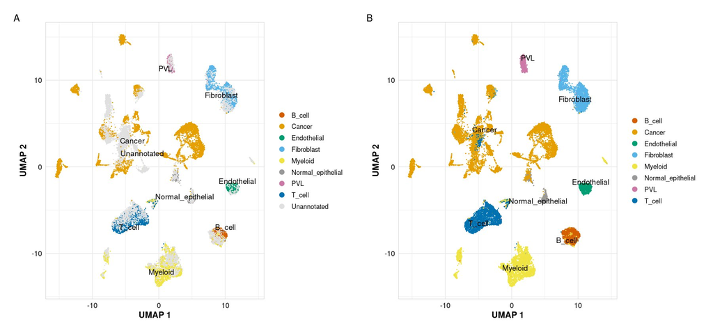

Figure 11: Cell types of the Pal cohort before (A, published labels) and after (B, harmonized classes) mapping to the common taxonomy.

```r
harmonization_plots[["pal"]]
```

**Wu**

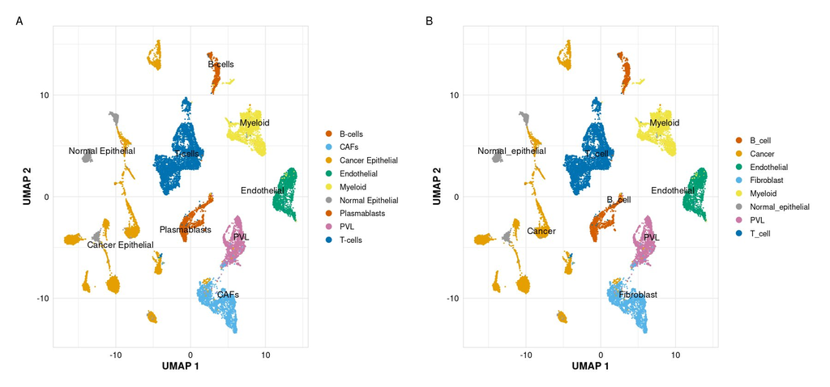

Figure 12: Cell types of the Wu cohort before (A, published labels) and after (B, harmonized classes) mapping to the common taxonomy.

```r
harmonization_plots[["wu"]]
```

**Qian**

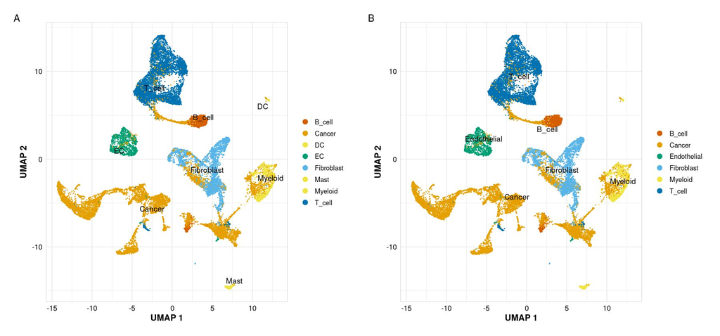

Figure 13: Cell types of the Qian cohort before (A, published labels) and after (B, harmonized classes) mapping to the common taxonomy.

```r
harmonization_plots[["qian"]]
```

### Marker-based check of the annotation

Each canonical marker should be enriched in its own class and low in the others: `EPCAM`, `KRT18` and `KRT19` in epithelial and cancer cells, `CD3D` and `CD3E` in T cells, `CD19` and `MS4A1` in B cells, `CD14` and `LYZ` in myeloid cells, `COL1A1` and `DCN` in fibroblasts, `PECAM1` and `VWF` in endothelial cells, and `ACTA2` and `RGS5` in PVL cells. The tables give the average log-normalized expression per class and the dot plots add the fraction of cells expressing each marker (Figure 14, Figure 15, Figure 16).

```r
seu_pal_annotated  <- seu_pal_sketched
seu_wu_annotated   <- seu_wu_sketched
seu_qian_annotated <- seu_qian_sketched
```

```r
canonical_markers_list <- list(
  Cancer_Epi = c("EPCAM", "KRT18", "KRT19"),
  T_cell     = c("CD3D", "CD3E"),
  B_cell     = c("CD19", "MS4A1"),
  Myeloid    = c("CD14", "LYZ"),
  Fibroblast = c("COL1A1", "DCN"),
  Endo       = c("PECAM1", "VWF"),
  PVL        = c("ACTA2", "RGS5")
)
validation_markers <- unname(unlist(canonical_markers_list))

marker_cohort_objs <- list(pal = seu_pal_annotated, wu = seu_wu_annotated, qian = seu_qian_annotated)
marker_tables <- lapply(marker_cohort_objs, function(seu) {
  existing_markers <- intersect(validation_markers, rownames(seu[["sketch"]]))
  expr <- Seurat::AverageExpression(seu, assays = "sketch", features = existing_markers, group.by = "harmonized_label", layer = "data")$sketch
  expr_df <- as.data.frame(expr)
  data.frame(Gene = rownames(expr_df), expr_df, check.names = FALSE)
})
for (coh in names(marker_tables)) {
  write.csv(marker_tables[[coh]], sprintf("results/characterization/%s_marker_expression.csv", coh), row.names = FALSE)
}

marker_plots <- lapply(marker_cohort_objs, function(seu) {
  plot_features <- lapply(canonical_markers_list, function(x) intersect(x, rownames(seu[["sketch"]])))
  plot_features <- plot_features[lengths(plot_features) > 0]
  Seurat::DotPlot(seu, features = plot_features, group.by = "harmonized_label", assay = "sketch") +
    labs(x = "Marker gene", y = "Harmonized cell type") +
    theme_publication() +
    theme(
      axis.text.x = element_text(angle = 45, hjust = 1, vjust = 1, face = "bold"),
      axis.text.y = element_text(face = "bold"),
      strip.text = element_blank(),
      strip.background = element_blank(),
      plot.margin = margin(t = 10, r = 10, b = 20, l = 20, unit = "pt")
    ) +
    scale_color_viridis_c(option = "viridis", direction = -1, name = "Mean expression")
})
for (coh in names(marker_plots)) {
  ggsave(sprintf("results/characterization/%s_marker_dotplot.png", coh), marker_plots[[coh]], width = 11, height = 6.5, dpi = 300)
}
```

````r
fig_tabs(
  c("```{r}",
    "#| label: tbl-markers-{{key}}",
    "#| eval: true",
    "#| tbl-cap: \"Average expression of the canonical markers per harmonized class in the {{title}} cohort.\"",
    "knitr::kable(marker_tables[[\"{{key}}\"]], digits = 2)",
    "```", "",
    "```{r}",
    "#| label: fig-markers-{{key}}",
    "#| eval: true",
    "#| fig-cap: \"Canonical marker expression per harmonized class in the {{title}} cohort. Dot size is the fraction of cells expressing the gene and color the mean expression.\"",
    "#| fig-width: 11",
    "#| fig-height: 6.5",
    "marker_plots[[\"{{key}}\"]]",
    "```", ""),
  keys = c("pal", "wu", "qian"),
  titles = c("Pal", "Wu", "Qian")
)
````

**Pal**

```r
knitr::kable(marker_tables[["pal"]], digits = 2)
```

Table 1: Average expression of the canonical markers per harmonized class in the Pal cohort.

|  | Gene | B-cell | Cancer | Endothelial | Fibroblast | Myeloid | Normal-epithelial | PVL | T-cell |
| --- | --- | --- | --- | --- | --- | --- | --- | --- | --- |
| RGS5 | RGS5 | 0.00 | 0.03 | 0.43 | 0.06 | 0.02 | 0.02 | 12.31 | 0.02 |
| EPCAM | EPCAM | 0.13 | 1.90 | 0.14 | 0.11 | 0.11 | 0.83 | 0.04 | 0.13 |
| CD14 | CD14 | 0.04 | 0.10 | 0.22 | 0.11 | 4.36 | 0.22 | 0.05 | 0.05 |
| MS4A1 | MS4A1 | 0.05 | 0.00 | 0.06 | 0.03 | 1.32 | 0.00 | 0.00 | 0.14 |
| CD3E | CD3E | 0.06 | 0.01 | 0.04 | 0.02 | 0.07 | 0.03 | 0.02 | 2.67 |
| CD3D | CD3D | 0.26 | 0.05 | 0.15 | 0.10 | 0.22 | 0.09 | 0.10 | 8.66 |
| ACTA2 | ACTA2 | 0.05 | 0.42 | 0.42 | 8.39 | 0.17 | 14.44 | 52.25 | 0.24 |
| VWF | VWF | 0.00 | 0.02 | 11.98 | 0.01 | 0.00 | 0.01 | 0.06 | 0.02 |
| KRT18 | KRT18 | 0.67 | 11.76 | 0.98 | 1.17 | 0.71 | 2.14 | 1.45 | 1.35 |
| LYZ | LYZ | 0.16 | 0.11 | 0.16 | 0.16 | 20.05 | 0.08 | 0.26 | 0.24 |
| DCN | DCN | 0.09 | 0.11 | 0.12 | 41.49 | 0.11 | 0.37 | 1.15 | 0.14 |
| CD19 | CD19 | 0.09 | 0.00 | 0.00 | 0.00 | 0.10 | 0.00 | 0.01 | 0.00 |
| KRT19 | KRT19 | 1.65 | 27.07 | 1.31 | 2.28 | 1.36 | 3.83 | 1.45 | 4.90 |
| COL1A1 | COL1A1 | 0.27 | 0.48 | 0.88 | 168.79 | 0.57 | 0.38 | 20.49 | 0.46 |
| PECAM1 | PECAM1 | 0.45 | 0.02 | 8.27 | 0.02 | 0.59 | 0.03 | 0.02 | 0.17 |

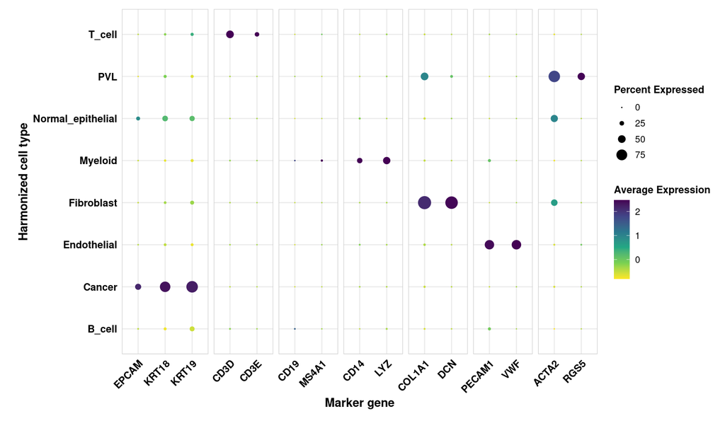

Figure 14: Canonical marker expression per harmonized class in the Pal cohort. Dot size is the fraction of cells expressing the gene and color the mean expression.

```r
marker_plots[["pal"]]
```

**Wu**

```r
knitr::kable(marker_tables[["wu"]], digits = 2)
```

Table 2: Average expression of the canonical markers per harmonized class in the Wu cohort.

|  | Gene | B-cell | Cancer | Endothelial | Fibroblast | Myeloid | Normal-epithelial | PVL | T-cell |
| --- | --- | --- | --- | --- | --- | --- | --- | --- | --- |
| RGS5 | RGS5 | 0.10 | 0.08 | 0.55 | 0.72 | 0.06 | 0.11 | 24.29 | 0.08 |
| EPCAM | EPCAM | 0.19 | 3.56 | 0.07 | 0.08 | 0.12 | 1.91 | 0.12 | 0.11 |
| CD14 | CD14 | 0.10 | 0.11 | 0.17 | 0.07 | 6.78 | 0.45 | 0.10 | 0.03 |
| MS4A1 | MS4A1 | 5.57 | 0.02 | 0.04 | 0.01 | 0.08 | 0.01 | 0.03 | 0.11 |
| CD3E | CD3E | 0.21 | 0.03 | 0.05 | 0.05 | 0.08 | 0.01 | 0.08 | 9.35 |
| CD3D | CD3D | 0.12 | 0.03 | 0.03 | 0.06 | 0.06 | 0.02 | 0.06 | 6.71 |
| ACTA2 | ACTA2 | 0.18 | 0.45 | 0.50 | 6.93 | 0.29 | 19.99 | 53.04 | 0.47 |
| VWF | VWF | 0.01 | 0.02 | 10.31 | 0.04 | 0.04 | 0.06 | 0.08 | 0.03 |
| KRT18 | KRT18 | 0.29 | 13.99 | 0.66 | 0.23 | 0.21 | 11.58 | 0.59 | 0.30 |
| LYZ | LYZ | 0.81 | 0.31 | 0.13 | 0.32 | 34.17 | 0.02 | 0.27 | 0.25 |
| DCN | DCN | 0.15 | 0.15 | 0.37 | 76.32 | 0.19 | 0.31 | 2.01 | 0.17 |
| CD19 | CD19 | 0.95 | 0.00 | 0.01 | 0.01 | 0.03 | 0.00 | 0.01 | 0.00 |
| KRT19 | KRT19 | 0.49 | 23.22 | 0.49 | 0.37 | 0.42 | 12.21 | 0.55 | 0.70 |
| COL1A1 | COL1A1 | 0.21 | 0.40 | 0.33 | 85.95 | 0.20 | 0.46 | 7.46 | 0.16 |
| PECAM1 | PECAM1 | 0.84 | 0.02 | 8.75 | 0.06 | 0.79 | 0.06 | 0.08 | 0.15 |

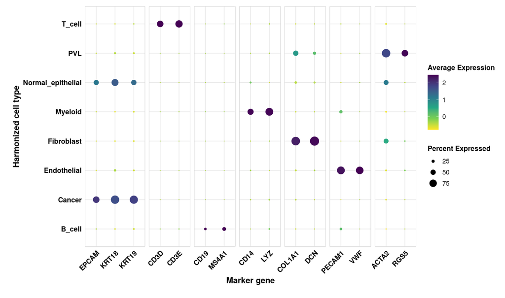

Figure 15: Canonical marker expression per harmonized class in the Wu cohort. Dot size is the fraction of cells expressing the gene and color the mean expression.

```r
marker_plots[["wu"]]
```

**Qian**

```r
knitr::kable(marker_tables[["qian"]], digits = 2)
```

Table 3: Average expression of the canonical markers per harmonized class in the Qian cohort.

|  | Gene | B-cell | Cancer | Endothelial | Fibroblast | Myeloid | T-cell |
| --- | --- | --- | --- | --- | --- | --- | --- |
| RGS5 | RGS5 | 0.05 | 0.69 | 0.41 | 6.14 | 0.06 | 0.03 |
| EPCAM | EPCAM | 0.01 | 1.21 | 0.12 | 0.11 | 0.01 | 0.04 |
| CD14 | CD14 | 0.01 | 0.49 | 0.15 | 0.09 | 6.87 | 0.02 |
| MS4A1 | MS4A1 | 14.63 | 0.25 | 0.02 | 0.03 | 0.00 | 0.22 |
| CD3E | CD3E | 0.07 | 0.50 | 0.08 | 0.07 | 0.12 | 11.92 |
| CD3D | CD3D | 0.02 | 0.32 | 0.03 | 0.07 | 0.06 | 7.20 |
| ACTA2 | ACTA2 | 0.13 | 2.88 | 0.33 | 13.45 | 0.15 | 0.36 |
| VWF | VWF | 0.01 | 0.07 | 13.36 | 0.03 | 0.03 | 0.03 |
| KRT18 | KRT18 | 0.11 | 4.57 | 0.51 | 0.35 | 0.08 | 0.18 |
| LYZ | LYZ | 0.12 | 3.57 | 0.30 | 0.43 | 17.25 | 0.12 |
| DCN | DCN | 0.22 | 4.00 | 0.68 | 38.75 | 0.23 | 0.22 |
| CD19 | CD19 | 2.82 | 0.06 | 0.00 | 0.00 | 0.01 | 0.00 |
| KRT19 | KRT19 | 0.18 | 12.96 | 0.97 | 0.73 | 0.31 | 0.36 |
| COL1A1 | COL1A1 | 0.51 | 14.26 | 1.47 | 209.68 | 0.81 | 0.98 |
| PECAM1 | PECAM1 | 0.35 | 0.21 | 11.55 | 0.06 | 0.98 | 0.33 |

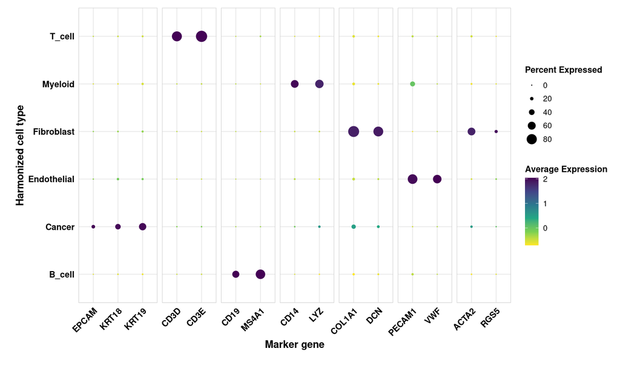

Figure 16: Canonical marker expression per harmonized class in the Qian cohort. Dot size is the fraction of cells expressing the gene and color the mean expression.

```r
marker_plots[["qian"]]
```

## Cell-type composition

Before inferring communication we check how the major cell types are represented in each cohort after quality control, since composition differences affect which interactions each cohort can detect (Figure 17). The table lists counts and percentages. Qian et al. has no PVL or normal epithelial annotation, so the Qian cohort has six of the eight classes.

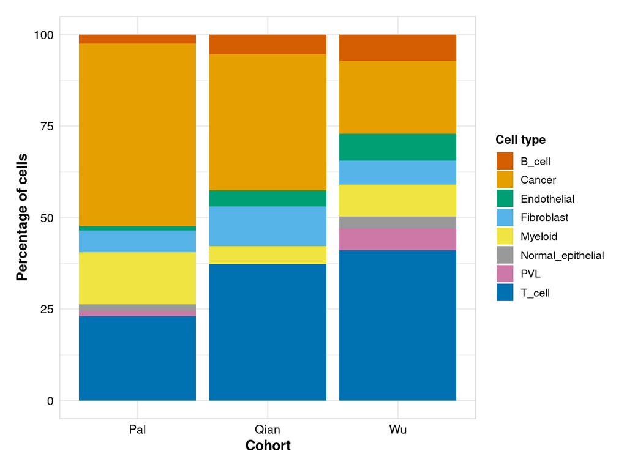

Figure 17: Cell-type composition of the discovery cohorts after quality control (all cells).

```r
get_comp <- function(seu, cohort_name) {
  tab <- table(seu$harmonized_label)
  df <- as.data.frame(tab)
  colnames(df) <- c("CellType", "Count")
  df$Percentage <- (df$Count / sum(df$Count)) * 100
  df$Cohort <- cohort_name
  return(df)
}

comp_pal <- get_comp(seu_pal_annotated, "Pal")
comp_wu <- get_comp(seu_wu_annotated, "Wu")
comp_qian <- get_comp(seu_qian_annotated, "Qian")

all_compositions <- bind_rows(comp_pal, comp_wu, comp_qian)
write_csv(all_compositions, "results/characterization/cohort_cell_compositions.csv")

p <- ggplot(all_compositions, aes(x = Cohort, y = Percentage, fill = CellType)) +
  geom_bar(stat = "identity", position = "stack") +
  labs(y = "Percentage of cells", x = "Cohort", fill = "Cell type") +
  scale_fill_manual(values = cell_type_colors) +
  theme_publication() +
  theme(legend.position = "right")

ggsave("results/characterization/cohort_composition_plot.png", plot = p, width = 8, height = 6, dpi = 300)
p
```

| CellType | Count | Percentage | Cohort |
| --- | --- | --- | --- |
| Cancer | 80195 | 49.94239451969485 | Pal |
| T_cell | 37147 | 23.13373812860035 | Pal |
| Myeloid | 22761 | 14.1746847267632 | Pal |
| Fibroblast | 9528 | 5.933675852405418 | Pal |
| B_cell | 3896 | 2.426280554258135 | Pal |
| Normal_epithelial | 2892 | 1.801027557216254 | Pal |
| PVL | 2189 | 1.363225906897088 | Pal |
| Endothelial | 1967 | 1.22497275416472 | Pal |
| T_cell | 11256 | 37.31971751599748 | Qian |
| Cancer | 11199 | 37.1307317396638 | Qian |

[output cut: 12 more lines]

Composition also differs by clinical subtype. The Qian cohort has no per-patient subtype and is not shown (Figure 18). T cells are more abundant in HER2+ tumors than in ER/PR+ tumors in both cohorts, in line with the higher immune infiltration usually reported for HER2+ disease.

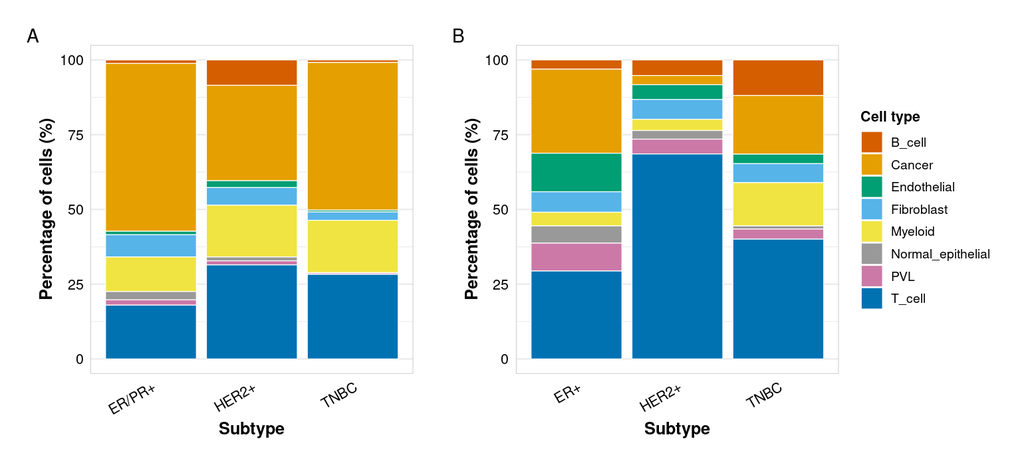

Figure 18: Cell-type composition by clinical subtype in the Pal (A) and Wu (B) cohorts.

```r
meta_pal <- readr::read_csv("data/meta/pal_primary_tumor_metadata.csv", show_col_types = FALSE) %>%
  dplyr::mutate(
    subtype = dplyr::case_when(
      grepl("Triple negative", title, ignore.case = TRUE) ~ "TNBC",
      grepl("HER2",            title, ignore.case = TRUE) ~ "HER2+",
      grepl("ER|PR",           title, ignore.case = TRUE) ~ "ER/PR+",
      TRUE                                                 ~ "Other"
    )
  ) %>%
  dplyr::select(gsm_id, subtype)

gsm_to_subtype <- setNames(meta_pal$subtype, meta_pal$gsm_id)

# Each cell barcode begins with the GSM accession separated by "_"
seu_pal_sketched$subtype <- unname(gsm_to_subtype[gsub("_.*", "", colnames(seu_pal_sketched))])

pal_comp <- seu_pal_sketched@meta.data %>%
  dplyr::filter(!is.na(subtype)) %>%
  dplyr::group_by(subtype, harmonized_label) %>%
  dplyr::summarise(Count = dplyr::n(), .groups = "drop") %>%
  dplyr::group_by(subtype) %>%
  dplyr::mutate(Percentage = Count / sum(Count) * 100) %>%
  dplyr::ungroup()

p_pal_sub <- ggplot(pal_comp, aes(x = subtype, y = Percentage, fill = harmonized_label)) +
  geom_bar(stat = "identity", position = "stack", colour = "white", linewidth = 0.3) +
  labs(
    x        = "Subtype",
    y        = "Percentage of cells (%)",
    fill     = "Cell type"
  ) +
  scale_fill_manual(values = cell_type_colors) +
  theme_publication() +
  theme(
    axis.text.x      = element_text(angle = 30, hjust = 1),
    panel.grid.major.x = element_blank(),
    legend.position  = "right"
  )

ggsave("results/characterization/pal_subtype_composition.png", plot = p_pal_sub, width = 8, height = 6, dpi = 300)

wu_dirs    <- list.dirs("data/raw/BCS014", full.names = FALSE, recursive = FALSE)
wu_sub_list <- lapply(wu_dirs, function(d) {
  m_path <- file.path("data/raw/BCS014", d, "metadata.csv")
  if (!file.exists(m_path)) return(NULL)
  m <- readr::read_csv(m_path, show_col_types = FALSE)
  # figshare barcode format: {sample_dir}_{cell_barcode}
  data.frame(
    figshare_barcode = paste0(d, "_", m$...1),
    subtype          = m$subtype,
    stringsAsFactors = FALSE
  )
})
wu_sub_all    <- dplyr::bind_rows(wu_sub_list)
wu_sub_lookup <- setNames(wu_sub_all$subtype, wu_sub_all$figshare_barcode)

seu_wu_sketched$subtype <- unname(wu_sub_lookup[colnames(seu_wu_sketched)])

wu_comp <- seu_wu_sketched@meta.data %>%
  dplyr::filter(!is.na(subtype)) %>%
  dplyr::group_by(subtype, harmonized_label) %>%
  dplyr::summarise(Count = dplyr::n(), .groups = "drop") %>%
  dplyr::group_by(subtype) %>%
  dplyr::mutate(Percentage = Count / sum(Count) * 100) %>%
  dplyr::ungroup()

p_wu_sub <- ggplot(wu_comp, aes(x = subtype, y = Percentage, fill = harmonized_label)) +
  geom_bar(stat = "identity", position = "stack", colour = "white", linewidth = 0.3) +
  labs(
    x        = "Subtype",
    y        = "Percentage of cells (%)",
    fill     = "Cell type"
  ) +
  scale_fill_manual(values = cell_type_colors) +
  theme_publication() +
  theme(
    axis.text.x      = element_text(angle = 30, hjust = 1),
    panel.grid.major.x = element_blank(),
    legend.position  = "right"
  )

ggsave("results/characterization/wu_subtype_composition.png", plot = p_wu_sub, width = 8, height = 6, dpi = 300)
(p_pal_sub + p_wu_sub) + plot_layout(guides = "collect") + plot_annotation(tag_levels = "A")
```

# Cell-cell communication

We infer ligand-receptor communication in each cohort with two frameworks that make different assumptions, CellChat and LIANA, and keep the interactions on which they agree in at least two cohorts. All inference runs on the harmonized, sketched objects, with the eight harmonized classes as senders and receivers.

## CellChat in each cohort

CellChat scores each ligand-receptor pair between every pair of cell types from the average expression of the ligand in the sender and of the receptor subunits in the receiver, with a permutation test for significance. We run it with the human CellChat database, the default trimean method on the log-normalized expression without network smoothing (`raw.use = TRUE`), and `min.cells = 10`, so that cell types with fewer than 10 cells are ignored. The first step defines the run and caches one object per cohort. The second step loads the caches.

```r
CellChatDB <- CellChatDB.human

run_cellchat_cohort <- function(seu, cohort_name, target_sketch) {
  message(sprintf("Running CellChat for %s cohort", cohort_name))

  seu_sub <- subset(seu, cells = colnames(seu[["sketch"]]))
  data.input <- GetAssayData(seu_sub, assay = "sketch", layer = "data")
  meta <- seu_sub@meta.data

  cellchat <- createCellChat(object = data.input, meta = meta, group.by = "harmonized_label")
  cellchat@DB <- CellChatDB

  cellchat <- subsetData(cellchat)
  cellchat <- identifyOverExpressedGenes(cellchat)
  cellchat <- identifyOverExpressedInteractions(cellchat)
  cellchat <- computeCommunProb(cellchat, raw.use = TRUE)
  cellchat <- filterCommunication(cellchat, min.cells = 10)

  cellchat <- computeCommunProbPathway(cellchat)
  cellchat <- aggregateNet(cellchat)

  cc_path <- sprintf("objects/cc_%s_%s.qs2", tolower(cohort_name), target_sketch)
  qs2::qs_save(cellchat, cc_path)
  message(sprintf("Finished CellChat and saved object to %s", cc_path))

  return(cellchat)
}
```

```r
if (file.exists(paste0("objects/cc_pal_", TARGET_SKETCH, ".qs2"))) {
  cc_pal <- qs2::qs_read(paste0("objects/cc_pal_", TARGET_SKETCH, ".qs2"))
  message("Loaded cached CellChat Pal object.")
} else {
  cc_pal <- run_cellchat_cohort(seu_pal_annotated, "Pal", TARGET_SKETCH)
}

if (file.exists(paste0("objects/cc_wu_", TARGET_SKETCH, ".qs2"))) {
  cc_wu <- qs2::qs_read(paste0("objects/cc_wu_", TARGET_SKETCH, ".qs2"))
  message("Loaded cached CellChat Wu object.")
} else {
  cc_wu <- run_cellchat_cohort(seu_wu_annotated, "Wu", TARGET_SKETCH)
}

if (file.exists(paste0("objects/cc_qian_", TARGET_SKETCH, ".qs2"))) {
  cc_qian <- qs2::qs_read(paste0("objects/cc_qian_", TARGET_SKETCH, ".qs2"))
  message("Loaded cached CellChat Qian object.")
} else {
  cc_qian <- run_cellchat_cohort(seu_qian_annotated, "Qian", TARGET_SKETCH)
}
```

```r
cc_pal <- qs2::qs_read(paste0("objects/cc_pal_", TARGET_SKETCH, ".qs2"))
cc_wu <- qs2::qs_read(paste0("objects/cc_wu_", TARGET_SKETCH, ".qs2"))
cc_qian <- qs2::qs_read(paste0("objects/cc_qian_", TARGET_SKETCH, ".qs2"))
cellchat_list <- list(Pal = cc_pal, Wu = cc_wu, Qian = cc_qian)
```

### Communication networks

The circle plots summarize the inferred network of each cohort: the number of significant interactions between cell types (left) and their total strength (right). The bubble plots list the significant ligand-receptor pairs that use cancer cells as senders (Figure 19, Figure 20 and the corresponding figures for Wu and Qian).

```r
dir.create("results/cellchat", showWarnings = FALSE, recursive = TRUE)

draw_cc_circles <- function(cc) {
  op <- par(mfrow = c(1, 2), mar = c(1, 1, 1, 1))
  CellChat::netVisual_circle(cc@net$count, weight.scale = TRUE, label.edge = FALSE, vertex.label.cex = 1.1)
  CellChat::netVisual_circle(cc@net$weight, weight.scale = TRUE, label.edge = FALSE, vertex.label.cex = 1.1)
  par(op)
}

cc_bubble_plots <- list()
for (coh in names(cellchat_list)) {
  cc <- cellchat_list[[coh]]
  cohort_lower <- tolower(coh)
  png(sprintf("results/cellchat/%s_circle_num.png", cohort_lower), width = 1000, height = 1000, res = 150)
  CellChat::netVisual_circle(cc@net$count, weight.scale = TRUE, label.edge = FALSE, vertex.label.cex = 0.8)
  dev.off()
  png(sprintf("results/cellchat/%s_circle_str.png", cohort_lower), width = 1000, height = 1000, res = 150)
  CellChat::netVisual_circle(cc@net$weight, weight.scale = TRUE, label.edge = FALSE, vertex.label.cex = 0.8)
  dev.off()
  p_bubble <- CellChat::netVisual_bubble(cc, sources.use = "Cancer", remove.isolate = FALSE, font.size = 10)
  ggsave(sprintf("results/cellchat/%s_bubble_key_pathways.png", cohort_lower), plot = p_bubble, width = 12, height = 8, dpi = 300, bg = "white")
  cc_bubble_plots[[cohort_lower]] <- p_bubble
}
```

````r
fig_tabs(
  c("```{r}",
    "#| label: fig-cellchat-circles-{{key}}",
    "#| eval: true",
    "#| fig-cap: \"CellChat network of the {{title}} cohort. Left, number of significant interactions between cell types; right, total interaction strength.\"",
    "#| fig-width: 11",
    "#| fig-height: 5.5",
    "draw_cc_circles(cellchat_list[[\"{{title}}\"]])",
    "```", "",
    "```{r}",
    "#| label: fig-cellchat-bubble-{{key}}",
    "#| eval: true",
    "#| fig-cap: \"Significant ligand-receptor pairs with cancer cells as senders in the {{title}} cohort. Dot color is the communication probability.\"",
    "#| fig-width: 12",
    "#| fig-height: 8",
    "cc_bubble_plots[[\"{{key}}\"]]",
    "```", ""),
  keys = c("pal", "wu", "qian"),
  titles = c("Pal", "Wu", "Qian")
)
````

**Pal**

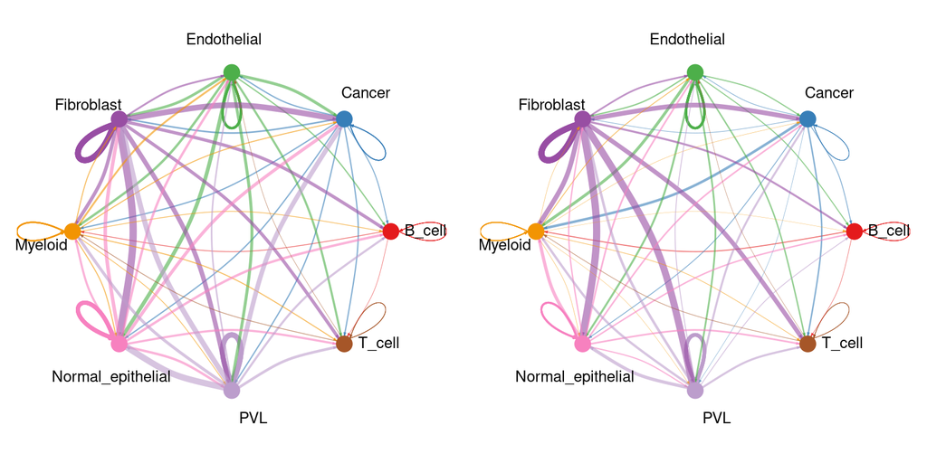

Figure 19: CellChat network of the Pal cohort. Left, number of significant interactions between cell types; right, total interaction strength.

```r
draw_cc_circles(cellchat_list[["Pal"]])
```

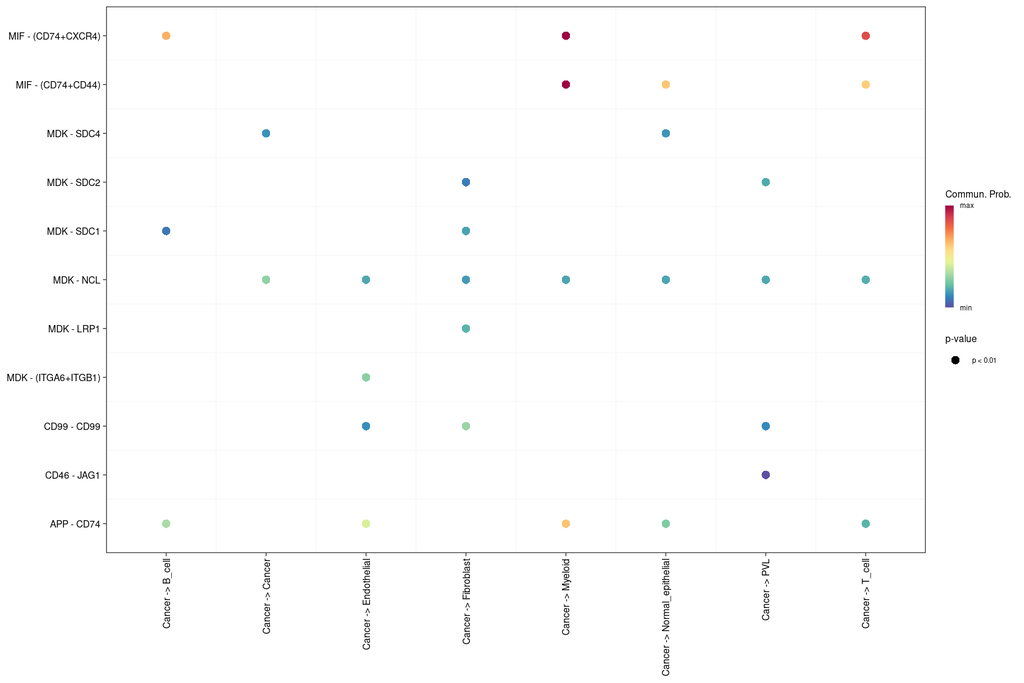

Figure 20: Significant ligand-receptor pairs with cancer cells as senders in the Pal cohort. Dot color is the communication probability.

```r
cc_bubble_plots[["pal"]]
```

**Wu**

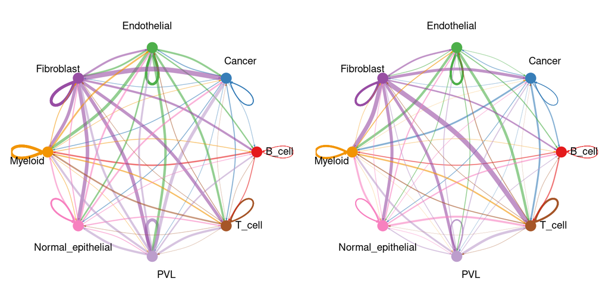

Figure 21: CellChat network of the Wu cohort. Left, number of significant interactions between cell types; right, total interaction strength.

```r
draw_cc_circles(cellchat_list[["Wu"]])
```

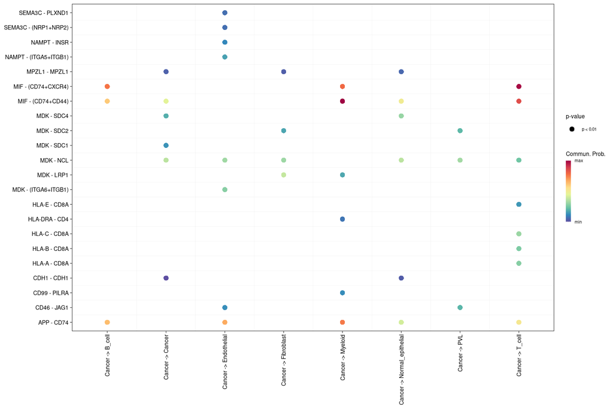

Figure 22: Significant ligand-receptor pairs with cancer cells as senders in the Wu cohort. Dot color is the communication probability.

```r
cc_bubble_plots[["wu"]]
```

**Qian**

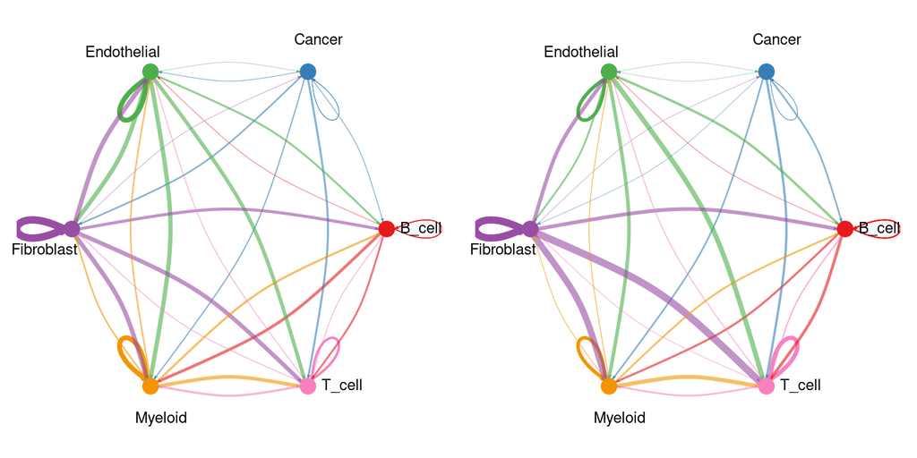

Figure 23: CellChat network of the Qian cohort. Left, number of significant interactions between cell types; right, total interaction strength.

```r
draw_cc_circles(cellchat_list[["Qian"]])
```

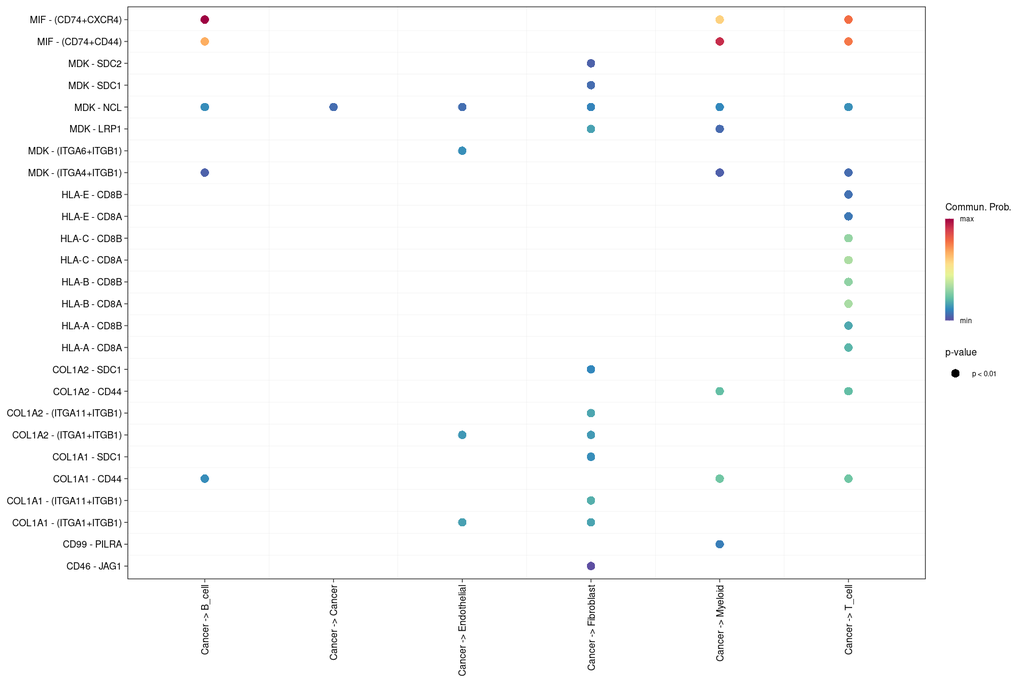

Figure 24: Significant ligand-receptor pairs with cancer cells as senders in the Qian cohort. Dot color is the communication probability.

```r
cc_bubble_plots[["qian"]]
```

### Significant interactions per cohort

The tables list every significant interaction of each cohort, ordered by communication probability.

```r
dir.create("results/cellchat", showWarnings = FALSE, recursive = TRUE)

extract_cc_interactions <- function(cc_obj, cohort_name) {
  df <- CellChat::subsetCommunication(cc_obj)

  df_clean <- df %>%
    dplyr::select(
      Source = source,
      Target = target,
      Ligand = ligand,
      Receptor = receptor,
      Pathway = pathway_name,
      Probability = prob,
      P_Value = pval
    ) %>%
    dplyr::arrange(desc(Probability))

  out_file <- sprintf("results/cellchat/%s_significant_interactions.csv", tolower(cohort_name))
  readr::write_csv(df_clean, out_file)
  message(sprintf("Saved %d significant interactions for %s cohort.", nrow(df_clean), cohort_name))
}

extract_cc_interactions(cc_pal, "Pal")
extract_cc_interactions(cc_wu, "Wu")
extract_cc_interactions(cc_qian, "Qian")
```

**Pal**

| Source | Target | Ligand | Receptor | Pathway | Probability | P_Value |
| --- | --- | --- | --- | --- | --- | --- |
| Endothelial | Myeloid | APP | CD74 | APP | 0.1604968918126116 | 0 |
| Normal_epithelial | Myeloid | APP | CD74 | APP | 0.1506629756222048 | 0 |
| Fibroblast | PVL | COL1A1 | ITGA1_ITGB1 | COLLAGEN | 0.125829650960693 | 0 |
| Fibroblast | PVL | COL1A2 | ITGA1_ITGB1 | COLLAGEN | 0.1232002196630298 | 0 |
| Cancer | Myeloid | MIF | CD74_CD44 | MIF | 0.09965500220386452 | 0 |
| Cancer | Myeloid | MIF | CD74_CXCR4 | MIF | 0.0990967388667027 | 0 |
| Endothelial | Endothelial | PECAM1 | PECAM1 | PECAM1 | 0.09329035557374211 | 0 |
| Endothelial | Endothelial | APP | CD74 | APP | 0.09023222883892353 | 0 |
| Fibroblast | T_cell | COL1A1 | CD44 | COLLAGEN | 0.08470432913047467 | 0 |
| Normal_epithelial | Endothelial | APP | CD74 | APP | 0.08427137745457132 | 0 |

[output cut: 425 more lines]

**Wu**

| Source | Target | Ligand | Receptor | Pathway | Probability | P_Value |
| --- | --- | --- | --- | --- | --- | --- |
| Endothelial | Myeloid | APP | CD74 | APP | 0.2094188203687256 | 0 |
| Normal_epithelial | Myeloid | APP | CD74 | APP | 0.1810734003958175 | 0 |
| Endothelial | Endothelial | APP | CD74 | APP | 0.1762145202669438 | 0 |
| Cancer | Myeloid | MIF | CD74_CD44 | MIF | 0.1754112899808624 | 0 |
| Cancer | T_cell | MIF | CD74_CXCR4 | MIF | 0.1711324348496357 | 0 |
| Endothelial | B_cell | APP | CD74 | APP | 0.1610235202740115 | 0 |
| Fibroblast | Fibroblast | CD99 | CD99 | CD99 | 0.1561707918930858 | 0 |
| Normal_epithelial | Endothelial | APP | CD74 | APP | 0.1515021356375549 | 0 |
| Normal_epithelial | Myeloid | MIF | CD74_CD44 | MIF | 0.1460732552344189 | 0 |
| Normal_epithelial | T_cell | MIF | CD74_CXCR4 | MIF | 0.142386475224369 | 0 |

[output cut: 762 more lines]

**Qian**

| Source | Target | Ligand | Receptor | Pathway | Probability | P_Value |
| --- | --- | --- | --- | --- | --- | --- |
| Endothelial | B_cell | APP | CD74 | APP | 0.2173024051460666 | 0 |
| Endothelial | Myeloid | APP | CD74 | APP | 0.2041721173360976 | 0 |
| Cancer | B_cell | MIF | CD74_CXCR4 | MIF | 0.1869496209150954 | 0 |
| Cancer | Myeloid | MIF | CD74_CD44 | MIF | 0.1670388156022173 | 0 |
| Fibroblast | B_cell | APP | CD74 | APP | 0.1664077154518661 | 0 |
| Endothelial | Endothelial | APP | CD74 | APP | 0.1602185668267264 | 0 |
| Fibroblast | Myeloid | APP | CD74 | APP | 0.155740775896295 | 0 |
| Myeloid | B_cell | MIF | CD74_CXCR4 | MIF | 0.1444033329206682 | 0 |
| T_cell | B_cell | MIF | CD74_CXCR4 | MIF | 0.1403053733602331 | 0 |
| Fibroblast | Myeloid | COL1A1 | CD44 | COLLAGEN | 0.1364759200904431 | 0 |

[output cut: 534 more lines]

## Conserved interactions

```r
dir.create("results/cross_cohort_comparison", showWarnings = FALSE, recursive = TRUE)

cellchat_list <- list(Pal = cc_pal, Wu = cc_wu, Qian = cc_qian)
merged_cellchat <- CellChat::mergeCellChat(cellchat_list, add.names = names(cellchat_list))

compare_df <- data.frame(
  Cohort = names(cellchat_list),
  Total_Interactions = sapply(cellchat_list, function(x) sum(x@net$count)),
  Total_Interaction_Strength = sapply(cellchat_list, function(x) sum(x@net$weight))
)
write_csv(compare_df, "results/cross_cohort_comparison/cellchat_interaction_comparison.csv")

p_count <- CellChat::compareInteractions(merged_cellchat, show.legend = FALSE, group = c(1, 2, 3), measure = "count") +
  scale_fill_manual(values = c("1" = "#56B4E9", "2" = "#CC79A7", "3" = "#E69F00")) +
  theme_publication() + theme(legend.position = "none")

p_weight <- CellChat::compareInteractions(merged_cellchat, show.legend = FALSE, group = c(1, 2, 3), measure = "weight") +
  scale_fill_manual(values = c("1" = "#56B4E9", "2" = "#CC79A7", "3" = "#E69F00")) +
  theme_publication() + theme(legend.position = "none")

p_compare <- p_count + p_weight + plot_annotation(tag_levels = "A")
ggsave("results/cross_cohort_comparison/cellchat_interaction_comparison.png", plot = p_compare, width = 10, height = 5, dpi = 300)
```

```r
cc_compare <- readr::read_csv("results/cross_cohort_comparison/cellchat_interaction_comparison.csv", show_col_types = FALSE)
knitr::kable(cc_compare, caption = "Comparison of Total Interaction Numbers and Strength Across Cohorts")
```

Table 4: Total number and strength of significant CellChat interactions per cohort.

Comparison of Total Interaction Numbers and Strength Across Cohorts

| Cohort | Total_Interactions | Total_Interaction_Strength |
| --- | --- | --- |
| Pal | 435 | 9.500808 |
| Wu | 772 | 17.884183 |
| Qian | 544 | 14.943916 |

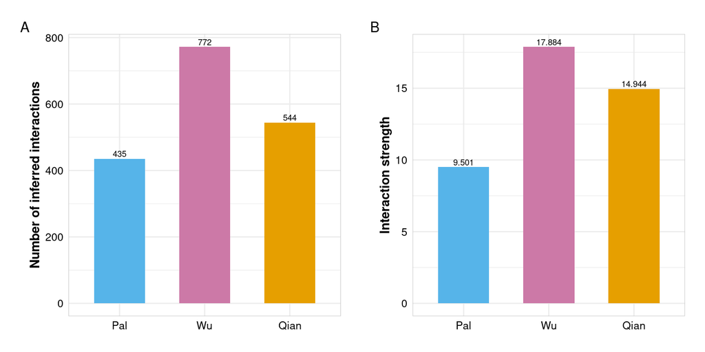

Figure 25: Total number (A) and strength (B) of significant interactions in the three cohorts.

```r
p_compare
```

The next step collapses the three cohorts into one table with a row per interaction and a count of the cohorts in which it is significant. Pairs significant in all three cohorts form the 3-of-3 set, and pairs in at least two cohorts form the 2-of-3 set.

```r
get_lr_df <- function(cc, cohort_name) {
  df <- CellChat::subsetCommunication(cc)
  if (is.null(df) || nrow(df) == 0) return(NULL)
  df$cohort <- cohort_name
  df$interaction_key <- paste(df$source, df$target, df$interaction_name, sep = " -> ")
  return(df)
}

df_pal <- get_lr_df(cc_pal, "Pal")
df_wu <- get_lr_df(cc_wu, "Wu")
df_qian <- get_lr_df(cc_qian, "Qian")

all_dfs <- list(df_pal, df_wu, df_qian) %>% purrr::keep(~!is.null(.))
combined_df <- dplyr::bind_rows(all_dfs)

interaction_summary <- combined_df %>%
  dplyr::group_by(source, target, ligand, receptor, interaction_name, interaction_key) %>%
  dplyr::summarise(
    cohorts_present = dplyr::n_distinct(cohort),
    mean_probability = mean(prob),
    cohorts_list = paste(sort(unique(cohort)), collapse = ", "),
    .groups = "drop"
  ) %>%
  dplyr::arrange(desc(cohorts_present), desc(mean_probability))

conserved_3_of_3 <- interaction_summary %>% dplyr::filter(cohorts_present == 3)
conserved_2_of_3 <- interaction_summary %>% dplyr::filter(cohorts_present >= 2)

write_csv(interaction_summary, "results/cross_cohort_comparison/all_interactions_summary.csv")
write_csv(conserved_3_of_3, "results/cross_cohort_comparison/conserved_interactions_3_of_3.csv")
write_csv(conserved_2_of_3, "results/cross_cohort_comparison/conserved_interactions_2_of_3.csv")

# Cancer as sender only — prevents a 10,000+ dot plot
p_bubble <- CellChat::netVisual_bubble(
  merged_cellchat,
  sources.use = "Cancer", # Cancer senders only, which keeps the plot to a readable size
  comparison = c(1, 2, 3),
  remove.isolate = FALSE
)
ggsave("results/cross_cohort_comparison/conserved_interactions_dotplot.png", plot = p_bubble, width = 11, height = 8, dpi = 300, bg = "white")
```

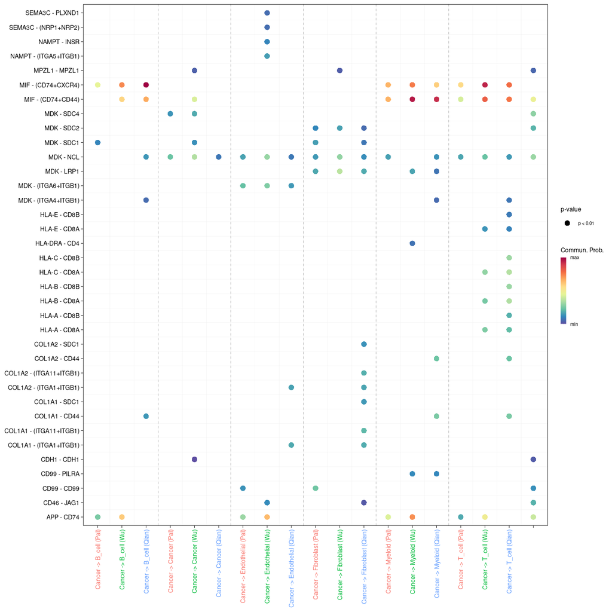

Figure 26: Ligand-receptor pairs with cancer cells as senders across the three cohorts (1, Pal; 2, Wu; 3, Qian). Dot color is the communication probability and dot size its significance.

```r
p_bubble
```

103 interactions are significant in all three cohorts and 545 in at least two. The tables below list the conserved interactions, ranked by the mean communication probability across the cohorts in which they are significant.

**Significant in all three cohorts**

| Source | Target | Ligand | Receptor | Mean_Probability |
| --- | --- | --- | --- | --- |
| Endothelial | Myeloid | APP | CD74 | 0.1913626098391449 |
| Cancer | Myeloid | MIF | CD74_CD44 | 0.1473683692623147 |
| Endothelial | B_cell | APP | CD74 | 0.1473559960985252 |
| Endothelial | Endothelial | APP | CD74 | 0.1422217719775312 |
| Cancer | T_cell | MIF | CD74_CXCR4 | 0.1271000352076704 |
| Endothelial | Endothelial | PECAM1 | PECAM1 | 0.119954241334925 |
| Cancer | B_cell | MIF | CD74_CXCR4 | 0.1192687048883091 |
| Fibroblast | T_cell | COL1A1 | CD44 | 0.1192344563485194 |
| Fibroblast | Fibroblast | CD99 | CD99 | 0.119019039339106 |
| Fibroblast | T_cell | COL1A2 | CD44 | 0.1180086001875766 |

[output cut: 93 more lines]

**Significant in exactly two cohorts**

| Source | Target | Ligand | Receptor | Cohorts | Mean_Probability |
| --- | --- | --- | --- | --- | --- |
| Normal_epithelial | Myeloid | APP | CD74 | Pal, Wu | 0.1658681880090112 |
| Normal_epithelial | Endothelial | APP | CD74 | Pal, Wu | 0.1178867565460631 |
| Normal_epithelial | Myeloid | MIF | CD74_CD44 | Pal, Wu | 0.1046635820865479 |
| Fibroblast | PVL | COL1A1 | ITGA1_ITGB1 | Pal, Wu | 0.1016953719494914 |
| T_cell | B_cell | MIF | CD74_CXCR4 | Qian, Wu | 0.1012871576066957 |
| Fibroblast | PVL | COL1A2 | ITGA1_ITGB1 | Pal, Wu | 0.1006189496476869 |
| Myeloid | B_cell | MIF | CD74_CXCR4 | Qian, Wu | 0.09889989273084132 |
| Normal_epithelial | B_cell | APP | CD74 | Pal, Wu | 0.09875066012561294 |
| Normal_epithelial | T_cell | MIF | CD74_CXCR4 | Pal, Wu | 0.09581737968461757 |
| Cancer | B_cell | MIF | CD74_CD44 | Qian, Wu | 0.09254404790548693 |

[output cut: 432 more lines]

## Conserved interactions in LIANA

CellChat is a single method, and different methods often disagree about which interactions are real. LIANA runs five methods on the same data, `natmi`, `connectome`, `logfc`, `sca` and `cellphonedb`, and aggregates their rankings with robust rank aggregation (RRA) into one score per interaction. We use the aggregate rank, with a threshold of 0.05, and require at least 10 cells per cell type and expression in at least 10% of the cells of the sender and receiver (`expr_prop = 0.1`). The CellChat and LIANA analyses are independent, and a pair that both frameworks detect in several cohorts is less likely to be an artifact of either.

```r
cohorts <- c("pal", "wu", "qian")
liana_results <- list()

for (cohort in cohorts) {
  out_csv <- paste0("results/liana/liana_", cohort, "_results.csv")
  if (file.exists(out_csv)) {
    liana_results[[cohort]] <- read_csv(out_csv, show_col_types = FALSE)
  } else {
    obj_path <- paste0("objects/seu_", cohort, "_harmonized_", TARGET_SKETCH, ".qs2")
    seu <- qs2::qs_read(obj_path)

    seu_sub <- subset(seu, cells = colnames(seu[["sketch"]]))
    DefaultAssay(seu_sub) <- "sketch"
    sce <- as.SingleCellExperiment(seu_sub, assay = "sketch")

    liana_res <- liana_wrap(
      sce,
      method = c("natmi", "connectome", "logfc", "sca", "cellphonedb"),
      idents_col = "harmonized_label",
      expr_prop = 0.1,
      min_cells = 10,
      permutation.params = list(nperms = 1000)
    )
    liana_agg <- liana_aggregate(liana_res)
    write_csv(liana_agg, out_csv)
    liana_results[[cohort]] <- liana_agg
  }
}
```

The next step rebuilds the conserved LIANA set from those per-cohort files, in the same way as for CellChat, and draws the dot plots of the strongest conserved interactions: first across all cell types, and then for each cell type as sender or receiver (Figure 27 and Figure 28, with the remaining cell types in the same tabset).

```r
liana_pal <- readr::read_csv("results/liana/liana_pal_results.csv", show_col_types = FALSE) %>%
  dplyr::mutate(cohort = "Pal") %>%
  dplyr::rename(ligand = ligand.complex, receptor = receptor.complex)
liana_wu <- readr::read_csv("results/liana/liana_wu_results.csv", show_col_types = FALSE) %>%
  dplyr::mutate(cohort = "Wu") %>%
  dplyr::rename(ligand = ligand.complex, receptor = receptor.complex)
liana_qian <- readr::read_csv("results/liana/liana_qian_results.csv", show_col_types = FALSE) %>%
  dplyr::mutate(cohort = "Qian") %>%
  dplyr::rename(ligand = ligand.complex, receptor = receptor.complex)

liana_all <- dplyr::bind_rows(liana_pal, liana_wu, liana_qian) %>%
  dplyr::filter(aggregate_rank <= 0.05) %>%
  dplyr::mutate(interaction_key = paste(source, target, ligand, receptor, sep = " -> "))

liana_conserved <- liana_all %>%
  dplyr::group_by(source, target, ligand, receptor, interaction_key) %>%
  dplyr::summarise(
    cohort_count = dplyr::n_distinct(cohort),
    mean_aggregate_rank = mean(aggregate_rank),
    cohorts_present = paste(sort(unique(cohort)), collapse = ", "),
    .groups = "drop"
  ) %>%
  dplyr::arrange(desc(cohort_count), mean_aggregate_rank)

readr::write_csv(liana_conserved, "results/cross_cohort_comparison/liana_conserved_all.csv")

top_overall <- liana_conserved %>% dplyr::filter(cohort_count == 3) %>% dplyr::slice_min(mean_aggregate_rank, n = 25)
plot_data_master <- liana_all %>% dplyr::filter(interaction_key %in% top_overall$interaction_key)

p_master <- ggplot(plot_data_master, aes(x = cohort, y = interaction_key, color = aggregate_rank, size = -log10(aggregate_rank + 1e-5))) +
  geom_point() +
  scale_color_viridis_c(direction = -1, name = "RRA rank") +
  labs(x = "Cohort", y = "Interaction (sender -> receiver -> ligand -> receptor)", size = "-log10(RRA rank)") +
  theme_publication() +
  theme(axis.text.x = element_text(angle = 45, hjust = 1, vjust = 1))

ggsave("results/cross_cohort_comparison/liana_conserved_bubble.png", plot = p_master, width = 12, height = 9, dpi = 300, bg = "white")

cell_types <- unique(c(liana_conserved$source, liana_conserved$target))
liana_ct_plots <- list()

for (ct in cell_types) {
  # Top 20 conserved interactions with this cell type as sender or receiver
  ct_conserved <- liana_conserved %>%
    dplyr::filter(cohort_count >= 2, (source == ct | target == ct)) %>%
    dplyr::slice_min(mean_aggregate_rank, n = 20)

  if (nrow(ct_conserved) == 0) next

  ct_plot_data <- liana_all %>% dplyr::filter(interaction_key %in% ct_conserved$interaction_key)

  p_ct <- ggplot(ct_plot_data, aes(x = cohort, y = interaction_key, color = aggregate_rank, size = -log10(aggregate_rank + 1e-5))) +
    geom_point() +
    scale_color_viridis_c(direction = -1, name = "RRA Rank") +
    labs(x = "Cohort", y = "Interaction (sender -> receiver -> ligand -> receptor)", size = "-log10(RRA rank)") +
    theme_publication() +
    theme(axis.text.x = element_text(angle = 45, hjust = 1, vjust = 1))

  safe_ct <- gsub(" ", "_", ct)
  liana_ct_plots[[safe_ct]] <- p_ct
  ggsave(sprintf("results/cross_cohort_comparison/conserved_dotplot_%s.png", safe_ct), plot = p_ct, width = 12, height = 8, dpi = 300, bg = "white")
}
```

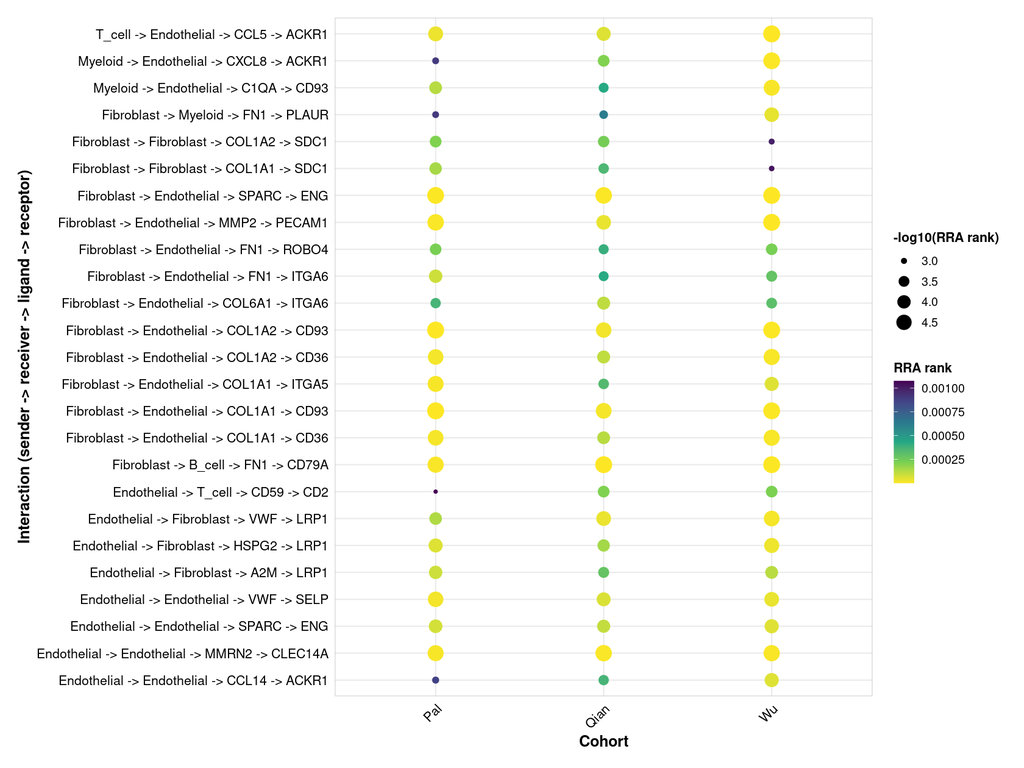

Figure 27: The 25 strongest ligand-receptor interactions conserved in all three cohorts according to LIANA. Color is the RRA rank (lower is stronger).

```r
p_master
```

````r
ct_keys <- c("Cancer", "Myeloid", "T_cell", "Fibroblast", "Endothelial", "B_cell", "PVL", "Normal_epithelial")
fig_tabs(
  c("```{r}",
    "#| label: fig-liana-celltype-{{key}}",
    "#| eval: true",
    "#| fig-cap: \"Top conserved LIANA interactions in which {{title}} cells are sender or receiver.\"",
    "#| fig-width: 12",
    "#| fig-height: 8",
    "liana_ct_plots[[\"{{key}}\"]]",
    "```", ""),
  keys = ct_keys,
  titles = gsub("_", " ", ct_keys)
)
````

**Cancer**

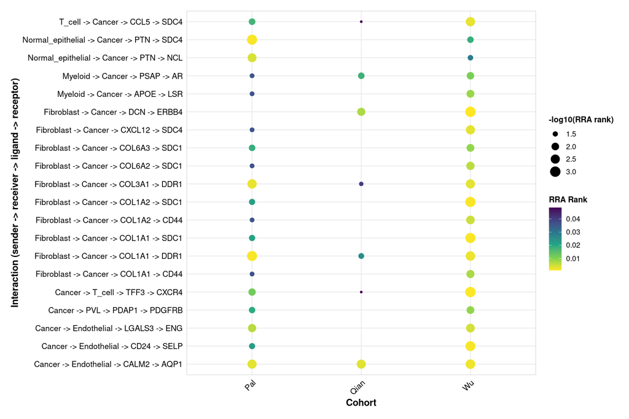

Figure 28: Top conserved LIANA interactions in which Cancer cells are sender or receiver.

```r
liana_ct_plots[["Cancer"]]
```

**Myeloid**

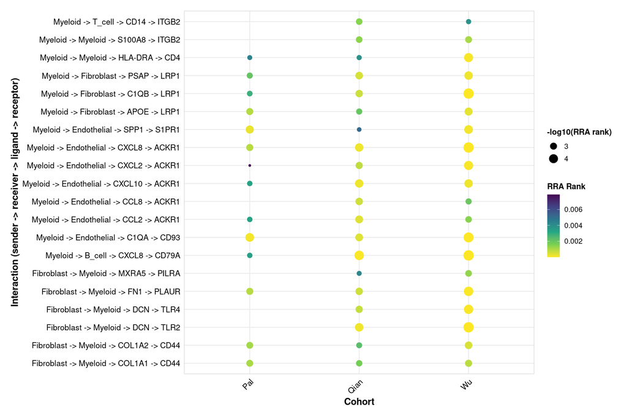

Figure 29: Top conserved LIANA interactions in which Myeloid cells are sender or receiver.

```r
liana_ct_plots[["Myeloid"]]
```

**T cell**

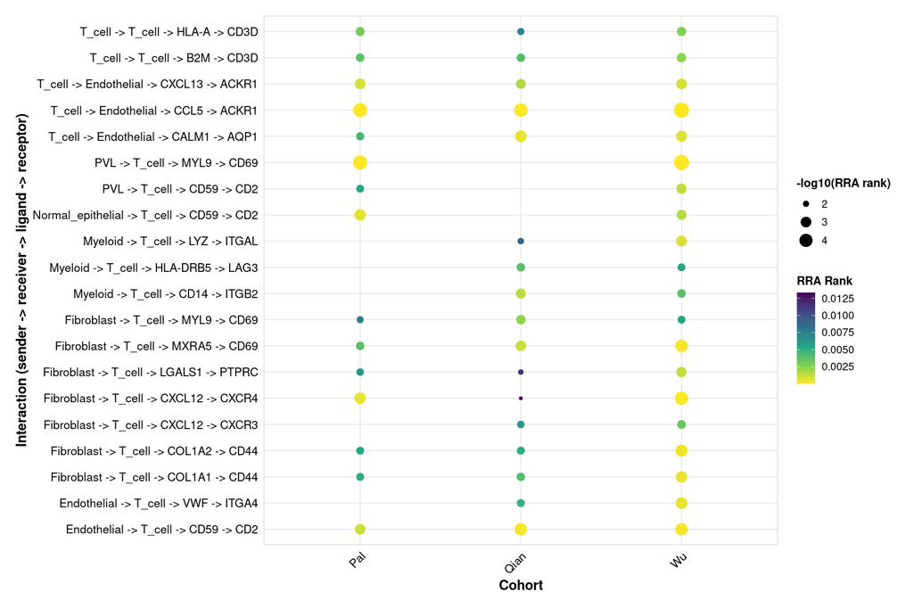

Figure 30: Top conserved LIANA interactions in which T cell cells are sender or receiver.

```r
liana_ct_plots[["T_cell"]]
```

**Fibroblast**

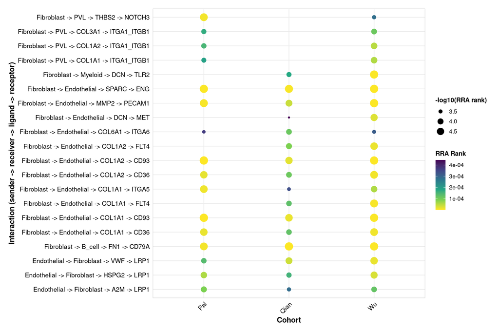

Figure 31: Top conserved LIANA interactions in which Fibroblast cells are sender or receiver.

```r
liana_ct_plots[["Fibroblast"]]
```

**Endothelial**

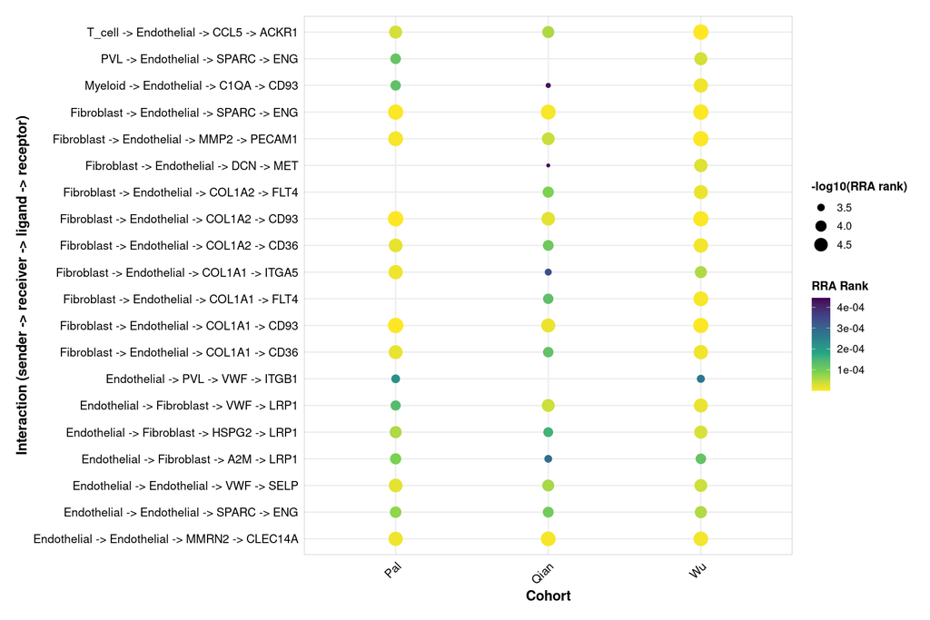

Figure 32: Top conserved LIANA interactions in which Endothelial cells are sender or receiver.

```r
liana_ct_plots[["Endothelial"]]
```

**B cell**